# BayesianOrdinationRegressionAnaLysis

```r
wave_lter5 <- wave_lter5 %>%
  mutate(
    # Replace -999 with NA for the key wave variables
    wave_ht_adcp_m = na_if(wave_ht_adcp_m, -999),
    wave_period_adcp_sec = na_if(wave_period_adcp_sec, -999),
    wave_power_adcp = na_if(wave_power_adcp, -999)
  )

str(wave_lter5)
```

```
## 'data.frame':    6925 obs. of  48 variables:
##  $ time_local                                          : POSIXct, format: "2005-07-24" "2005-07-25" ...
##  $ time_utc                                            : POSIXct, format: "2005-07-24 10:00:00" "2005-07-25 10:00:00" ...
##  $ along_shore_velocity_bottom_mps                     : num  -999 -999 -999 -999 -999 -999 -999 -999 -999 -999 ...
##  $ data_coverage_along_shore_velocity_bottom_mps       : num  0 0 0 0 0 0 0 0 0 0 ...
##  $ along_shore_velocity_surface_mps                    : num  -999 -999 -999 -999 -999 -999 -999 -999 -999 -999 ...
##  $ data_coverage_along_shore_velocity_surface_mps      : num  0 0 0 0 0 0 0 0 0 0 ...
##  $ across_shore_velocity_bottom_mps                    : num  -999 -999 -999 -999 -999 -999 -999 -999 -999 -999 ...
##  $ data_coverage_across_shore_velocity_bottom_mps      : num  0 0 0 0 0 0 0 0 0 0 ...
##  $ across_shore_velocity_surface_mps                   : num  -999 -999 -999 -999 -999 -999 -999 -999 -999 -999 ...
##  $ data_coverage_across_shore_velocity_surface_mps     : num  0 0 0 0 0 0 0 0 0 0 ...
##  $ current_speed_bottom_mps                            : num  -999 -999 -999 -999 -999 -999 -999 -999 -999 -999 ...
##  $ data_coverage_current_speed_bottom_mps              : num  0 0 0 0 0 0 0 0 0 0 ...
##  $ current_speed_surface_mps                           : num  -999 -999 -999 -999 -999 -999 -999 -999 -999 -999 ...
##  $ data_coverage_current_speed_surface_mps             : num  0 0 0 0 0 0 0 0 0 0 ...
```

[output cut: 34 more lines]

```r
names(wave_lter5)
```

```
##  [1] "time_local"
##  [2] "time_utc"
##  [3] "along_shore_velocity_bottom_mps"
##  [4] "data_coverage_along_shore_velocity_bottom_mps"
##  [5] "along_shore_velocity_surface_mps"
##  [6] "data_coverage_along_shore_velocity_surface_mps"
##  [7] "across_shore_velocity_bottom_mps"
##  [8] "data_coverage_across_shore_velocity_bottom_mps"
##  [9] "across_shore_velocity_surface_mps"
## [10] "data_coverage_across_shore_velocity_surface_mps"
## [11] "current_speed_bottom_mps"
## [12] "data_coverage_current_speed_bottom_mps"
## [13] "current_speed_surface_mps"
## [14] "data_coverage_current_speed_surface_mps"
## [15] "wave_power_adcp"
```

[output cut: 33 more lines]

```r
head(wave_lter5)
```

```
##   time_local            time_utc along_shore_velocity_bottom_mps
## 1 2005-07-24 2005-07-24 10:00:00                            -999
## 2 2005-07-25 2005-07-25 10:00:00                            -999
## 3 2005-07-26 2005-07-26 10:00:00                            -999
## 4 2005-07-27 2005-07-27 10:00:00                            -999
## 5 2005-07-28 2005-07-28 10:00:00                            -999
## 6 2005-07-29 2005-07-29 10:00:00                            -999
##   data_coverage_along_shore_velocity_bottom_mps
## 1                                             0
## 2                                             0
## 3                                             0
## 4                                             0
## 5                                             0
## 6                                             0
##   along_shore_velocity_surface_mps
```

[output cut: 181 more lines]

3.3 Function for Calculating Wave Power

```r
#Calculate P = wave energy flux (kW m–1)
#From Dean & Dalrymple (1991)
#P = wave energy flux (W m⁻¹)
#ρ=1028 kg m⁻³ (seawater density)
#g=9.8 m s⁻²
#Hsig = significant wave height (m)
#T = dominant wave period (s)

rho <- 1028     # seawater density
g <- 9.8        # gravity


process_wave_site <- function(dat, shore_label, start_date = "2017-01-01") {

  dat_clean <- dat %>%
    mutate(
      wave_ht_adcp_m       = na_if(wave_ht_adcp_m, -999),
      wave_period_adcp_sec = na_if(wave_period_adcp_sec, -999),
      wave_power_adcp      = na_if(wave_power_adcp, -999),
      Hsig = wave_ht_adcp_m,
      T    = wave_period_adcp_sec,
      P_wm  = (rho * g^2 * Hsig^2 * T) / (64 * pi),
      P_kwm = P_wm / 1000
    )

  daily <- dat_clean %>%
    mutate(date = as.Date(time_local)) %>%
    group_by(date) %>%
    summarise(
      wave_power_adcp   = mean(wave_power_adcp,   na.rm = TRUE),
      wave_ht_adcp_m    = mean(wave_ht_adcp_m,    na.rm = TRUE),
      wave_period_adcp  = mean(wave_period_adcp_sec, na.rm = TRUE),
      P_kwm             = mean(P_kwm, na.rm = TRUE),
      .groups = "drop"
    )

  clim <- daily %>%
    filter(date >= as.Date(start_date)) %>%
    summarise(
      P_mean = mean(P_kwm, na.rm = TRUE),
      P_p95  = quantile(P_kwm, 0.95, na.rm = TRUE),
      P_max  = max(P_kwm, na.rm = TRUE),
      P_sd   = sd(P_kwm, na.rm = TRUE)
    ) %>%
    mutate(shore = shore_label)

  list(daily = daily, clim = clim)
}
```

3.4 Calculate Wave Power

```r
#LTER_1
res_lter1 <- process_wave_site(wave_lter1, shore_label = "North")
wave_lter1_daily <- res_lter1$daily
wave_lter1_clim  <- res_lter1$clim

#LTER_4
res_lter4 <- process_wave_site(wave_lter4, shore_label = "East")
wave_lter4_daily <- res_lter4$daily
wave_lter4_clim  <- res_lter4$clim

#LTER_5
res_lter5 <- process_wave_site(wave_lter5, shore_label = "West")
wave_lter5_daily <- res_lter5$daily
wave_lter5_clim  <- res_lter5$clim
```

3.5 Plot daily P_kwm for all 3 sites on the same axes

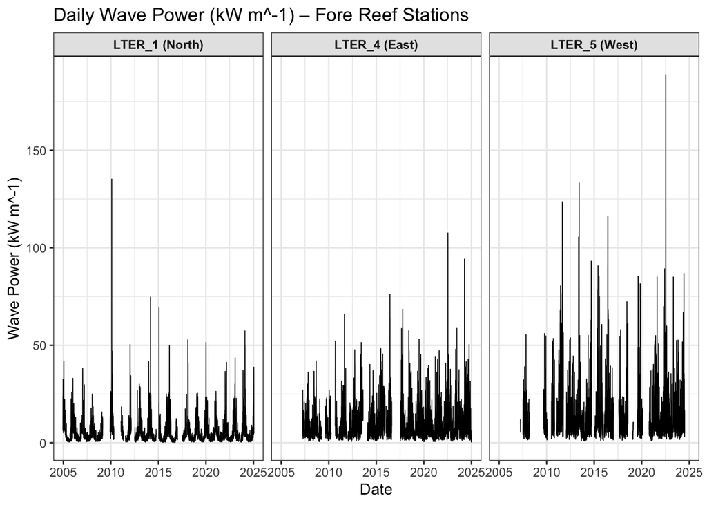

```r
wave_daily_all <- bind_rows(
  wave_lter1_daily %>% mutate(site = "LTER_1 (North)"),
  wave_lter4_daily %>% mutate(site = "LTER_4 (East)"),
  wave_lter5_daily %>% mutate(site = "LTER_5 (West)")
)

ggplot(wave_daily_all, aes(x = date, y = P_kwm)) +
  geom_line(linewidth = 0.3) +
  facet_wrap(~ site, nrow = 1, scales = "fixed") +  # same y-axis across facets
  labs(
    title = "Daily Wave Power (kW m^-1) – Fore Reef Stations",
    x = "Date",
    y = "Wave Power (kW m^-1)"
  ) +
  theme_bw() +
  theme(
    strip.background = element_rect(fill = "grey90"),
    strip.text = element_text(face = "bold")
  )
```

3.6 Build the shore-level wave table for the JSDM

```r
wave_shore <- bind_rows(
  wave_lter1_clim,
  wave_lter4_clim,
  wave_lter5_clim
) %>%
  select(shore, P_mean, P_p95, P_max, P_sd)

wave_shore
```

```
## # A tibble: 3 × 5
##   shore P_mean P_p95 P_max  P_sd
##   <chr>  <dbl> <dbl> <dbl> <dbl>
## 1 North   4.84  15.4  57.4  5.49
## 2 East    9.16  24.3 108.   8.45
## 3 West   13.1   36.4 189.  12.7
```

```r
sites_wave <- sites %>%
  left_join(wave_shore, by = "shore")

str(sites_wave)
```

```
## tibble [11 × 8] (S3: tbl_df/tbl/data.frame)
##  $ long     : num [1:11] -150 -150 -150 -150 -150 ...
##  $ lat      : num [1:11] -17.6 -17.6 -17.6 -17.5 -17.5 ...
##  $ site.name: chr [1:11] "S11" "S12" "S14" "S15" ...
##  $ shore    : chr [1:11] "East" "West" "West" "West" ...
##  $ P_mean   : num [1:11] 9.16 13.08 13.08 13.08 13.08 ...
##  $ P_p95    : Named num [1:11] 24.3 36.4 36.4 36.4 36.4 ...
##   ..- attr(*, "names")= chr [1:11] "95%" "95%" "95%" "95%" ...
##  $ P_max    : num [1:11] 108 189 189 189 189 ...
##  $ P_sd     : num [1:11] 8.45 12.68 12.68 12.68 12.68 ...
```

4. Lagoon temperature: site-level from SBE56 array Temperature

4.1 Downloading temperature data

```r
# Package ID: knb-lter-mcr.1045.6 Cataloging System:https://pasta.edirepository.org.
# Data set title: MCR LTER: Coral Reef: Island-Wide Lagoon Benthic Water Temperature, ongoing since 2021.
# Data set creator:    - Moorea Coral Reef LTER
# Data set creator:  Tom Adam - Moorea Coral Reef LTER
# Data set creator:  James Hench - Moorea Coral Reef LTER
# Data set creator:  Andrew Brooks - Moorea Coral Reef LTER
# Metadata Provider:    - Moorea Coral Reef LTER
# Contact:    - Information Manager Moorea Coral Reef LTER  - mcrlter@msi.ucsb.edu
# Stylesheet v2.15 for metadata conversion into program: John H. Porter, Univ. Virginia, jporter@virginia.edu
# Uncomment the following lines to have R clear previous work, or set a working directory
# rm(list=ls())

# setwd("C:/users/my_name/my_dir")

options(HTTPUserAgent = "EDI_CodeGen")

## ---------- 1. Daily lagoon temperature (rename dt1 → temp_daily) ----------

temp_url  <- "https://pasta.lternet.edu/package/data/eml/knb-lter-mcr/1045/6/7a8090507e95d40ba98d837388f7c506"
temp_file <- tempfile()

try(
  download.file(
    temp_url,
    temp_file,
    method = "curl",
    extra = paste0(' -A "', getOption("HTTPUserAgent"), '"')
  )
)

if (is.na(file.size(temp_file))) {
  download.file(temp_url, temp_file, method = "auto")
}

lagoon_temp_daily <- read.csv(
  temp_file,
  header   = FALSE,
  skip     = 1,
  sep      = ",",
  quote    = '"',
  col.names = c(
    "site",
    "date_local",
    "min_temp_c",
    "max_temp_c",
    "median_temp_c",
    "mean_temp_c"
  ),
  check.names = TRUE
)

unlink(temp_file)

## Type fixes / parsing (no attach)

lagoon_temp_daily <- lagoon_temp_daily %>%
  mutate(
    site = as.factor(site),
    # parse date
    date_local = as.Date(date_local, format = "%Y-%m-%d"),
    # numeric temps
    across(
      c(min_temp_c, max_temp_c, median_temp_c, mean_temp_c),
      ~ suppressWarnings(as.numeric(.))
    )
  )

str(lagoon_temp_daily)
```

```
## 'data.frame':    61077 obs. of  6 variables:
##  $ site         : Factor w/ 49 levels "B01","B02","B03",..: 10 11 12 13 14 15 16 17 18 19 ...
##  $ date_local   : Date, format: "2021-08-07" "2021-08-07" ...
##  $ min_temp_c   : num  26.9 26.9 26.9 26.9 26.9 ...
##  $ max_temp_c   : num  27.5 27.5 27.5 27.5 27.5 ...
##  $ median_temp_c: num  27 27 27.2 27.1 27.1 ...
##  $ mean_temp_c  : num  27.1 27.1 27.2 27.2 27.2 ...
```

```r
summary(lagoon_temp_daily$site)
```

```
##   B01   B02   B03   B04   B05   B06   B07   B08   B09   B10 B10.5   B11   B12
##   883  1092  1030  1345  1458  1144  1320  1458  1140  1461  1417  1461  1461
##   B13   B14   B15   B16   B17   B18   B19   B20   B21   B22   B23   B24   B25
##  1147  1449  1238  1056  1071  1461  1461  1359  1461  1034   360  1104  1452
##   B26   B27   B28   B29   B30   B31   B32   B33   B34   B35   E01   E02   E03
##  1450  1250  1064  1452  1096  1452  1452  1402   984  1064  1077  1077  1032
##   E04   N01   N02   N03   N04   N05   W01   W02   W04   W05
##   831  1459  1459  1181  1459  1276  1450  1249  1452  1086
```

```r
summary(lagoon_temp_daily$mean_temp_c)
```

```
##    Min. 1st Qu.  Median    Mean 3rd Qu.    Max.
##   24.91   26.96   27.86   27.84   28.64   30.36
```

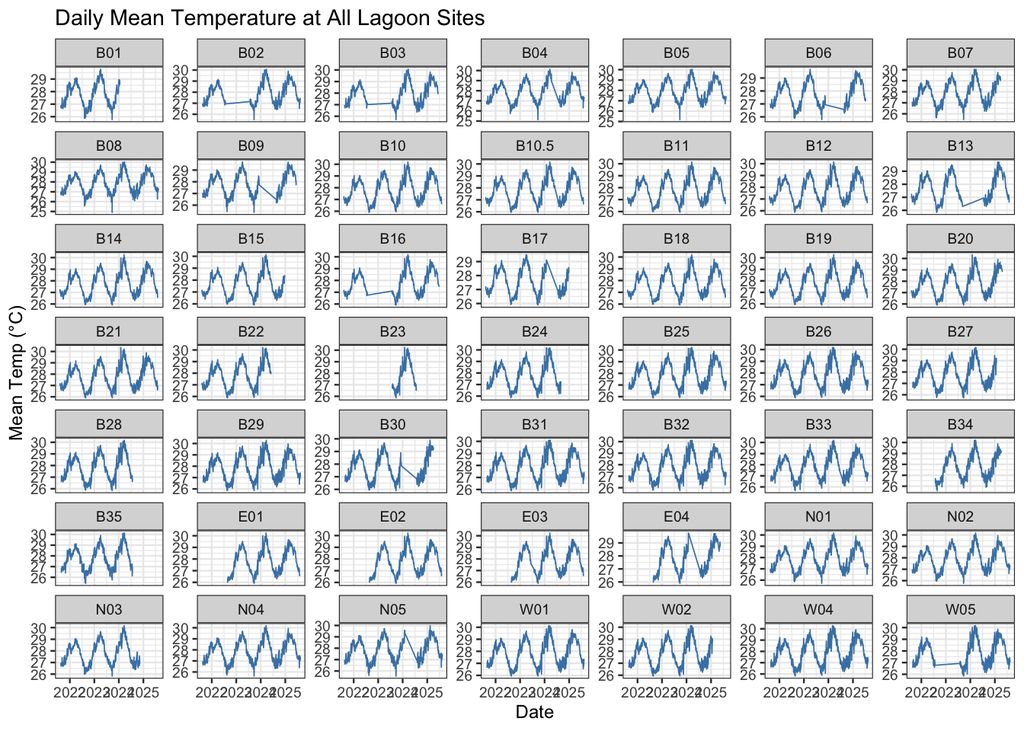

```r
#plot mean data to look for outliers
ggplot(lagoon_temp_daily, aes(x = date_local, y = mean_temp_c)) +
  geom_line(color = "steelblue", linewidth = 0.3) +
  facet_wrap(~ site, scales = "free_y", ncol = 7) +
  theme_bw(base_size = 9) +
  labs(
    title = "Daily Mean Temperature at All Lagoon Sites",
    x = "Date",
    y = "Mean Temp (°C)"
  )
```

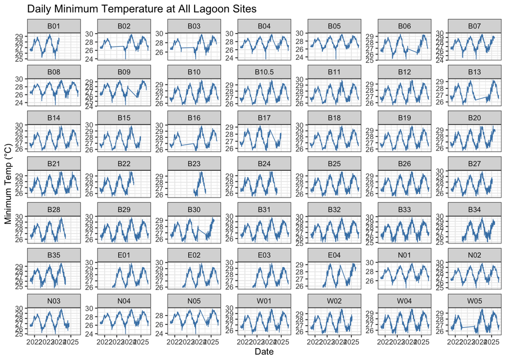

```r
#plot min data to look for outliers
ggplot(lagoon_temp_daily, aes(x = date_local, y = min_temp_c)) +
  geom_line(color = "steelblue", linewidth = 0.3) +
  facet_wrap(~ site, scales = "free_y", ncol = 7) +
  theme_bw(base_size = 9) +
  labs(
    title = "Daily Minimum Temperature at All Lagoon Sites",
    x = "Date",
    y = "Minimum Temp (°C)"
  )
```

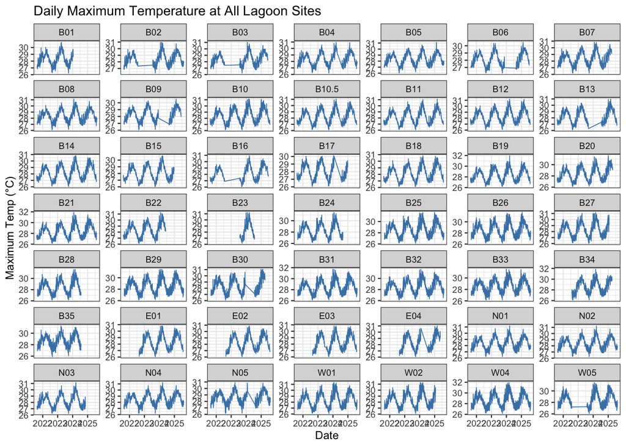

```r
#plot max data to look for outliers
ggplot(lagoon_temp_daily, aes(x = date_local, y = max_temp_c)) +
  geom_line(color = "steelblue", linewidth = 0.3) +
  facet_wrap(~ site, scales = "free_y", ncol = 7) +
  theme_bw(base_size = 9) +
  labs(
    title = "Daily Maximum Temperature at All Lagoon Sites",
    x = "Date",
    y = "Maximum Temp (°C)"
  )
```

```r
## ---------- 2. Site–filename lookup (rename dt2 → temp_files) ----------

temp_meta_url  <- "https://pasta.lternet.edu/package/data/eml/knb-lter-mcr/1045/6/aa66754bc0fec207b813ee970389ad93"
temp_meta_file <- tempfile()

try(
  download.file(
    temp_meta_url,
    temp_meta_file,
    method = "curl",
    extra = paste0(' -A "', getOption("HTTPUserAgent"), '"')
  )
)

if (is.na(file.size(temp_meta_file))) {
  download.file(temp_meta_url, temp_meta_file, method = "auto")
}

lagoon_temp_files <- read.csv(
  temp_meta_file,
  header   = FALSE,
  skip     = 1,
  sep      = ",",
  quote    = '"',
  col.names = c("site_code", "filename"),
  check.names = TRUE
)

unlink(temp_meta_file)

lagoon_temp_files <- lagoon_temp_files %>%
  mutate(
    site_code = as.factor(site_code),
    filename  = as.factor(filename)
  )

str(lagoon_temp_files)
```

```
## 'data.frame':    49 obs. of  2 variables:
##  $ site_code: Factor w/ 49 levels "B01","B02","B03",..: 1 2 3 4 5 6 7 8 9 10 ...
##  $ filename : Factor w/ 49 levels "MCR_B01_Lagoon_BottomMountThermistor",..: 1 2 3 4 5 6 7 8 9 10 ...
```

```r
summary(lagoon_temp_files$site_code)
```

```
##   B01   B02   B03   B04   B05   B06   B07   B08   B09   B10 B10.5   B11   B12
##     1     1     1     1     1     1     1     1     1     1     1     1     1
##   B13   B14   B15   B16   B17   B18   B19   B20   B21   B22   B23   B24   B25
##     1     1     1     1     1     1     1     1     1     1     1     1     1
##   B26   B27   B28   B29   B30   B31   B32   B33   B34   B35   E01   E02   E03
##     1     1     1     1     1     1     1     1     1     1     1     1     1
##   E04   N01   N02   N03   N04   N05   W01   W02   W04   W05
##     1     1     1     1     1     1     1     1     1     1
```

4.2 Summarize temperature data

```r
lagoon_temp_summary <- lagoon_temp_daily %>%
  group_by(site) %>%
  summarise(
    mean_temp        = mean(mean_temp_c, na.rm = TRUE),
    median_temp      = median(median_temp_c, na.rm = TRUE),
    max_temp         = max(max_temp_c, na.rm = TRUE),
    p95_temp         = quantile(max_temp_c, 0.95, na.rm = TRUE),
    sd_temp          = sd(mean_temp_c, na.rm = TRUE),
    mean_daily_range = mean(max_temp_c - min_temp_c, na.rm = TRUE),
    freq_above_30C   = mean(max_temp_c > 30, na.rm = TRUE),
    n_days           = sum(!is.na(mean_temp_c)),
    .groups = "drop"
  )

lagoon_temp_summary
```

```
## # A tibble: 49 × 9
##    site  mean_temp median_temp max_temp p95_temp sd_temp mean_daily_range
##    <fct>     <dbl>       <dbl>    <dbl>    <dbl>   <dbl>            <dbl>
##  1 B01        27.7        27.7     30.8     29.7   0.880            0.815
##  2 B02        28.0        28.0     31.0     30.0   0.906            0.760
##  3 B03        28.0        28.1     31.0     29.9   0.917            0.693
##  4 B04        27.9        27.9     31.0     29.9   0.957            0.731
##  5 B05        27.9        27.9     31.1     29.8   0.945            0.673
##  6 B06        27.8        27.7     30.5     29.6   0.925            0.638
##  7 B07        27.9        27.9     30.8     29.9   0.963            0.792
##  8 B08        27.9        27.9     31.1     29.9   0.954            0.856
##  9 B09        27.8        27.8     30.6     29.7   0.934            0.805
## 10 B10        27.8        27.8     31.1     30.2   0.981            0.849
## # ℹ 39 more rows
## # ℹ 2 more variables: freq_above_30C <dbl>, n_days <int>
```

```r
lagoon_coords <- tribble(
  ~site,   ~long,      ~lat,
  # Backbone B01–B35
  "B01",   -149.89,    -17.485,
  "B02",   -149.879,   -17.484,
  "B03",   -149.868,   -17.487,
  "B04",   -149.85,    -17.482,
  "B05",   -149.833,   -17.479,
  "B06",   -149.817,   -17.475,
  "B07",   -149.806,   -17.475,
  "B08",   -149.793,   -17.475,
  "B09",   -149.784,   -17.473,
  "B10",   -149.761,   -17.503,
  "B10.5", -149.763,   -17.508,
  "B11",   -149.765,   -17.520,
  "B12",   -149.765,   -17.530,
  "B13",   -149.764,   -17.535,
  "B14",   -149.767,   -17.541,
  "B15",   -149.783,   -17.561,
  "B16",   -149.787,   -17.569,
  "B17",   -149.789,   -17.580,
  "B18",   -149.791,   -17.587,
  "B19",   -149.799,   -17.599,
  "B20",   -149.808,   -17.603,
  "B21",   -149.817,   -17.603,
  "B22",   -149.827,   -17.603,
  "B23",   -149.836,   -17.599,
  "B24",   -149.853,   -17.593,
  "B25",   -149.861,   -17.590,
  "B26",   -149.867,   -17.585,
  "B27",   -149.882,   -17.568,
  "B28",   -149.885,   -17.562,
  "B29",   -149.892,   -17.555,
  "B30",   -149.897,   -17.550,
  "B31",   -149.902,   -17.545,
  "B32",   -149.913,   -17.535,
  "B33",   -149.922,   -17.513,
  "B34",   -149.924,   -17.504,
  "B35",   -149.923,   -17.495,

  # North transect N01–N05
  "N01",   -149.84593, -17.48063,
  "N02",   -149.84624, -17.48011,
  "N03",   -149.84657, -17.47915,
  "N04",   -149.84544, -17.48146,
  "N05",   -149.84500, -17.48200,

  # West transect W01–W05
  "W01",   -149.86800, -17.58630,
  "W02",   -149.86721, -17.58585,
  "W04",   -149.86654, -17.58431,
  "W05",   -149.86600, -17.58300,

  # East transect E01–E04
  "E01",   -149.76600, -17.54090,
  "E02",   -149.76600, -17.54110,
  "E03",   -149.76800, -17.54030,
  "E04",   -149.76800, -17.53970
)

lagoon_temp_full <- lagoon_temp_summary %>%
  left_join(lagoon_coords, by = "site")
```

4.3 Map temperature data to coral sites

```r
ph_coords  <- as.matrix(sites[, c("long", "lat")])
temp_coords <- as.matrix(lagoon_temp_full[, c("long", "lat")])

dist_mat_temp <- distm(ph_coords, temp_coords, fun = distHaversine)

nn_temp_idx <- apply(dist_mat_temp, 1, which.min)
dist_to_temp_m <- apply(dist_mat_temp, 1, min)

#join
sites_temp <- sites %>%
  mutate(
    temp_site         = lagoon_temp_full$site[nn_temp_idx],
    temp_long         = lagoon_temp_full$long[nn_temp_idx],
    temp_lat          = lagoon_temp_full$lat[nn_temp_idx],
    mean_temp_br      = lagoon_temp_full$mean_temp[nn_temp_idx],
    median_temp_br    = lagoon_temp_full$median_temp[nn_temp_idx],
    max_temp_br       = lagoon_temp_full$max_temp[nn_temp_idx],
    p95_temp_br       = lagoon_temp_full$p95_temp[nn_temp_idx],
    daily_range_br    = lagoon_temp_full$mean_daily_range[nn_temp_idx],
    sd_temp_br        = lagoon_temp_full$sd_temp[nn_temp_idx],
    freq_above_30C_br = lagoon_temp_full$freq_above_30C[nn_temp_idx],
    dist_to_temp_m    = dist_to_temp_m
  )

#inspect
sites_temp %>%
  select(site.name, shore, temp_site, dist_to_temp_m,
         mean_temp_br, max_temp_br, p95_temp_br, daily_range_br)
```

```
## # A tibble: 11 × 8
##    site.name shore temp_site dist_to_temp_m mean_temp_br max_temp_br p95_temp_br
##    <chr>     <fct> <chr>              <dbl>        <dbl>       <dbl>       <dbl>
##  1 S11       East  B20                375.          27.8        31.6        30.2
##  2 S12       West  B24                598.          27.8        31.4        30.0
##  3 S14       West  B28                359.          27.9        31.7        30.3
##  4 S15       West  B31                215.          27.9        31.7        30.3
##  5 S18       West  B35                168.          27.8        31.3        30.3
##  6 S2        North B04                282.          27.9        31.0        29.9
##  7 S3        North B05                182.          27.9        31.1        29.8
##  8 S4        North B07                191.          27.9        30.8        29.9
##  9 S5        North B09                 46.0         27.8        30.6        29.7
## 10 S6        East  B10.5              297.          27.9        31.0        30.0
## 11 S9        East  B16                482.          27.9        30.9        29.9
## # ℹ 1 more variable: daily_range_br <dbl>
```

```r
str(sites_temp)
```

```
## tibble [11 × 15] (S3: tbl_df/tbl/data.frame)
##  $ long             : num [1:11] -150 -150 -150 -150 -150 ...
##  $ lat              : num [1:11] -17.6 -17.6 -17.6 -17.5 -17.5 ...
##  $ site.name        : chr [1:11] "S11" "S12" "S14" "S15" ...
##  $ shore            : Factor w/ 3 levels "West","North",..: 3 1 1 1 1 2 2 2 2 3 ...
##  $ temp_site        : chr [1:11] "B20" "B24" "B28" "B31" ...
##  $ temp_long        : num [1:11] -150 -150 -150 -150 -150 ...
##  $ temp_lat         : num [1:11] -17.6 -17.6 -17.6 -17.5 -17.5 ...
##  $ mean_temp_br     : num [1:11] 27.8 27.8 27.9 27.9 27.8 ...
##  $ median_temp_br   : num [1:11] 27.8 27.8 27.8 27.8 27.8 ...
##  $ max_temp_br      : num [1:11] 31.6 31.4 31.7 31.7 31.3 ...
##  $ p95_temp_br      : Named num [1:11] 30.2 30 30.3 30.3 30.3 ...
##   ..- attr(*, "names")= chr [1:11] "95%" "95%" "95%" "95%" ...
##  $ daily_range_br   : num [1:11] 0.918 0.815 0.988 0.956 1.382 ...
##  $ sd_temp_br       : num [1:11] 1.014 1.014 1.014 1.005 0.989 ...
##  $ freq_above_30C_br: num [1:11] 0.0831 0.0525 0.0921 0.1006 0.1043 ...
##  $ dist_to_temp_m   : num [1:11] 375 598 359 215 168 ...
```

5. Benthic cover: backreef photoquadrats, block-level

5.1 Download benthic cover data and clean

```r
# Package ID: knb-lter-mcr.1038.14 Cataloging System:https://pasta.edirepository.org.
# Data set title: MCR LTER: Coral Reef: Long-term Community Dynamics: Backreef (Lagoon) Corals Annual Survey, ongoing since 2005.
# Data set creator:    - Moorea Coral Reef LTER
# Data set creator:  Peter Edmunds - Moorea Coral Reef LTER
# Metadata Provider:  Hillary Krumbholz - MCR LTER
# Contact:    - Information Manager MCR LTER  - hkrumbholz@ucsb.edu

options(HTTPUserAgent = "EDI_CodeGen")

# URL for table 1 (simple cover: coral / macroalgae / sand / millepora / ctb)
benthic_simple_url <-
  "https://pasta.lternet.edu/package/data/eml/knb-lter-mcr/1038/14/b7ca625d17a5630441af8c229cc0ab92"

benthic_simple_file <- tempfile()

try(
  download.file(
    benthic_simple_url,
    benthic_simple_file,
    method = "curl",
    extra = paste0(' -A "', getOption("HTTPUserAgent"), '"')
  ),
  silent = TRUE
)

if (is.na(file.size(benthic_simple_file))) {
  download.file(benthic_simple_url, benthic_simple_file, method = "auto")
}

# Read cleanly
benthic_simple_raw <- read_csv(
  benthic_simple_file,
  skip = 1,
  col_names = c(
    "year", "site", "habitat", "depth", "quad", "patch",
    "coral", "macroalgae", "sand", "millepora", "ctb",
    "sub_squares", "note"
  ),
  na = c("na", "NA", "BW", "")
)
unlink(benthic_simple_file)

benthic_simple <- benthic_simple_raw %>%
  mutate(
    site    = as.factor(site),
    habitat = as.factor(habitat),
    quad    = as.factor(quad),
    patch   = as.factor(patch),
    note    = as.factor(note),
    depth   = suppressWarnings(as.numeric(depth)),
    across(where(is.character))  # ensures numeric cols clean
  )
```

5.2 Process downloaded benthic cover data and map to sites

```r
# 1) Filter to backreef/lagoon habitat and summarise by site
benthic_br_site <- benthic_simple %>%
  # keep lagoon/backreef habitats; tweak this if you see slightly different labels
  filter(grepl("back", habitat, ignore.case = TRUE) |
         grepl("lagoon", habitat, ignore.case = TRUE)) %>%
  mutate(
    # Make sure site is character, then create LTER-style ID
    lter_site = as.character(site)
  ) %>%
  group_by(lter_site) %>%
  summarise(
    coral_cover      = mean(coral,      na.rm = TRUE),
    macroalgae_cover = mean(macroalgae, na.rm = TRUE),
    sand_cover       = mean(sand,       na.rm = TRUE),
    millepora_cover  = mean(millepora,  na.rm = TRUE),
    ctb_cover        = mean(ctb,        na.rm = TRUE),
    .groups = "drop"
  )

benthic_br_site
```

```
## # A tibble: 6 × 6
##   lter_site coral_cover macroalgae_cover sand_cover millepora_cover ctb_cover
##   <chr>           <dbl>            <dbl>      <dbl>           <dbl>     <dbl>
## 1 LTER_1           16.5            11.7        18.4         0.0758       53.3
## 2 LTER_2           11.2            18.2        23.8         0.0129       45.8
## 3 LTER_3           24.3             7.07       28.6         0.00664      39.6
## 4 LTER_4           36.8             5.29       22.1         0.614        35.2
## 5 LTER_5           25.0             3.56       33.5         1.12         36.7
## 6 LTER_6           28.2             1.68       19.8         0.441        49.8
```

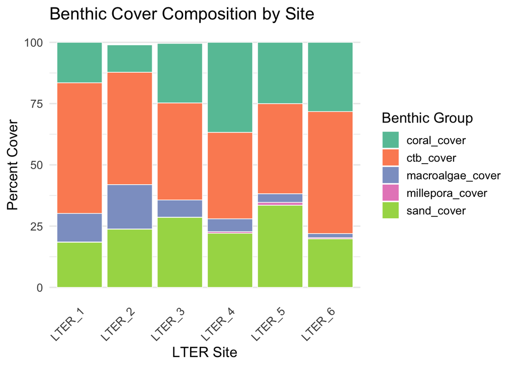

```r
benthic_long <- benthic_br_site %>%
  pivot_longer(
    cols = -lter_site,
    names_to = "cover_type",
    values_to = "percent_cover"
  )

ggplot(benthic_long, aes(x = lter_site, y = percent_cover, fill = cover_type)) +
  geom_col(color = "white", linewidth = 0.3) +
  scale_fill_brewer(palette = "Set2") +
  labs(
    title = "Benthic Cover Composition by Site",
    x = "LTER Site",
    y = "Percent Cover",
    fill = "Benthic Group"
  ) +
  theme_minimal(base_size = 14) +
  theme(
    panel.grid.major.x = element_blank(),
    axis.text.x = element_text(angle = 45, hjust = 1)
  )
```

```r
backreef_coords <- tribble(
  ~site,    ~long,        ~lat,
  "LTER_1", -149.8425765, -17.47823787,
  "LTER_2", -149.8033863, -17.47700229,
  "LTER_3", -149.7643003, -17.51396455,
  "LTER_4", -149.7696695, -17.54318109,
  "LTER_5", -149.8714356, -17.57932994,
  "LTER_6", -149.9210026, -17.52112157
)

# Join coordinates with benthic means
backreef_benthic <- backreef_coords %>%
  left_join(benthic_br_site, by = c("site" = "lter_site"))

## 1. Coordinate matrices: PH sites and backreef sites ----

# Make sure 'sites' has columns: site.name, long, lat
# And 'backreef_benthic' has: site, long, lat, coral_cover, macroalgae_cover, ctb_cover, sand_cover, millepora_cover

ph_coords       <- as.matrix(sites[, c("long", "lat")])
backreef_coords <- as.matrix(backreef_benthic[, c("long", "lat")])

## 2. Distance matrix + nearest neighbor index ----

# Distance matrix (meters): rows = PH sites, cols = LTER backreef sites
dist_mat <- distm(ph_coords, backreef_coords, fun = distHaversine)

# Index of nearest backreef site for each PH site
nn_idx <- apply(dist_mat, 1, which.min)

# Minimum distance (m) to the matched backreef site
dist_to_br_m <- apply(dist_mat, 1, min)

## 3. Attach nearest backreef benthic info to PH sites ----

sites_benthic <- sites %>%
  mutate(
    br_site             = backreef_benthic$site[nn_idx],
    br_long             = backreef_benthic$long[nn_idx],
    br_lat              = backreef_benthic$lat[nn_idx],
    coral_cover_br      = backreef_benthic$coral_cover[nn_idx],
    macroalgae_cover_br = backreef_benthic$macroalgae_cover[nn_idx],
    ctb_cover_br        = backreef_benthic$ctb_cover[nn_idx],
    sand_cover_br       = backreef_benthic$sand_cover[nn_idx],
    millepora_cover_br  = backreef_benthic$millepora_cover[nn_idx],
    dist_to_br_m        = dist_to_br_m
  )

## 4. Inspect the mapping ----

sites_benthic %>%
  select(site.name, shore,
         br_site, dist_to_br_m,
         coral_cover_br, macroalgae_cover_br, ctb_cover_br,
         sand_cover_br, millepora_cover_br)
```

```
## # A tibble: 11 × 9
##    site.name shore br_site dist_to_br_m coral_cover_br macroalgae_cover_br
##    <chr>     <fct> <chr>          <dbl>          <dbl>               <dbl>
##  1 S11       East  LTER_5         7570.           25.0                3.56
##  2 S12       West  LTER_5         3060.           25.0                3.56
##  3 S14       West  LTER_5         2064.           25.0                3.56
##  4 S15       West  LTER_6         3552.           28.2                1.68
##  5 S18       West  LTER_6         3059.           28.2                1.68
##  6 S2        North LTER_1         1158.           16.5               11.7
##  7 S3        North LTER_1          864.           16.5               11.7
##  8 S4        North LTER_2          475.           11.2               18.2
##  9 S5        North LTER_2         2150.           11.2               18.2
## 10 S6        East  LTER_3          961.           24.3                7.07
## 11 S9        East  LTER_4         2931.           36.8                5.29
## # ℹ 3 more variables: ctb_cover_br <dbl>, sand_cover_br <dbl>,
## #   millepora_cover_br <dbl>
```

```r
str(sites_benthic)
```

```
## tibble [11 × 13] (S3: tbl_df/tbl/data.frame)
##  $ long               : num [1:11] -150 -150 -150 -150 -150 ...
##  $ lat                : num [1:11] -17.6 -17.6 -17.6 -17.5 -17.5 ...
##  $ site.name          : chr [1:11] "S11" "S12" "S14" "S15" ...
##  $ shore              : Factor w/ 3 levels "West","North",..: 3 1 1 1 1 2 2 2 2 3 ...
##  $ br_site            : chr [1:11] "LTER_5" "LTER_5" "LTER_5" "LTER_6" ...
##  $ br_long            : num [1:11] -150 -150 -150 -150 -150 ...
##  $ br_lat             : num [1:11] -17.6 -17.6 -17.6 -17.5 -17.5 ...
##  $ coral_cover_br     : num [1:11] 25 25 25 28.2 28.2 ...
##  $ macroalgae_cover_br: num [1:11] 3.56 3.56 3.56 1.68 1.68 ...
##  $ ctb_cover_br       : num [1:11] 36.7 36.7 36.7 49.8 49.8 ...
##  $ sand_cover_br      : num [1:11] 33.5 33.5 33.5 19.8 19.8 ...
##  $ millepora_cover_br : num [1:11] 1.119 1.119 1.119 0.441 0.441 ...
##  $ dist_to_br_m       : num [1:11] 7570 3060 2064 3552 3059 ...
```

6. Fish functional groups: backreef fish, block-level

```r
# Package ID: knb-lter-mcr.6.64 Cataloging System:https://pasta.edirepository.org.
# Data set title: MCR LTER: Coral Reef: Long-term Population and Community Dynamics: Fishes, ongoing since 2005.
# Data set creator:    - Moorea Coral Reef LTER
# Data set creator:  Andrew Brooks - Moorea Coral Reef LTER
# Metadata Provider:    - Moorea Coral Reef LTER
# Contact:    - Information Manager Moorea Coral Reef LTER  - mcrlter@msi.ucsb.edu

#Read the main fish observations table (dt1 → fish_main)

options(HTTPUserAgent = "EDI_CodeGen")

## ---------- Main fish table ----------

fish_main_url  <- "https://pasta.lternet.edu/package/data/eml/knb-lter-mcr/6/64/ac2c7a859ce8595ec1339e8530b9ba50"
fish_main_file <- tempfile()

try(
  download.file(
    fish_main_url,
    fish_main_file,
    method = "curl",
    extra  = paste0(' -A "', getOption("HTTPUserAgent"), '"')
  ),
  silent = TRUE
)

if (is.na(file.size(fish_main_file))) {
  download.file(fish_main_url, fish_main_file, method = "auto")
}

fish_main <- read.csv(
  fish_main_file,
  header = FALSE,
  skip   = 1,
  sep    = ",",
  quote  = '"',
  col.names = c(
    "Year",
    "Date",
    "Start",
    "End",
    "Location",
    "Site",
    "Habitat",
    "Depth",
    "Transect",
    "Swath",
    "Taxonomy",
    "Family",
    "Count",
    "Total_Length",
    "Length_Anomaly",
    "Biomass",
    "Comment",
    "Coarse_Trophic",
    "Fine_Trophic",
    "Cloud_Cover",
    "Wind_Velocity",
    "Sea_State",
    "Swell",
    "Visibility",
    "Surge",
    "Diver"
  ),
  stringsAsFactors = FALSE,
  check.names = TRUE
)

unlink(fish_main_file)

#Clean up types & sentinel values
fish_main <- fish_main %>%
  mutate(
    Date  = as.Date(Date, format = "%Y-%m-%d"),
    Start = as.factor(Start),
    End   = as.factor(End),

    Location = as.factor(Location),
    Site     = as.factor(Site),
    Habitat  = as.factor(Habitat),
    Transect = as.factor(Transect),
    Swath    = as.factor(Swath),

    Taxonomy = ifelse(Taxonomy == "No fish observed", NA, Taxonomy),
    Taxonomy = as.factor(Taxonomy),
    Family   = as.factor(Family),

    # numeric fields
    Depth         = suppressWarnings(as.numeric(Depth)),
    Count         = suppressWarnings(as.numeric(Count)),
    Total_Length  = suppressWarnings(as.numeric(Total_Length)),
    Biomass       = suppressWarnings(as.numeric(Biomass)),
    Cloud_Cover   = suppressWarnings(as.numeric(Cloud_Cover)),
    Wind_Velocity = suppressWarnings(as.numeric(Wind_Velocity)),
    Sea_State     = suppressWarnings(as.numeric(Sea_State)),
    Swell         = suppressWarnings(as.numeric(Swell)),
    Visibility    = suppressWarnings(as.numeric(Visibility)),
    Surge         = suppressWarnings(as.numeric(Surge)),

    Length_Anomaly = ifelse(Length_Anomaly == "na", NA, Length_Anomaly),
    Length_Anomaly = as.factor(Length_Anomaly),

    Comment       = ifelse(Comment == "NA", NA, Comment),
    Comment       = as.factor(Comment),

    Coarse_Trophic = ifelse(Coarse_Trophic == "na", NA, Coarse_Trophic),
    Coarse_Trophic = as.factor(Coarse_Trophic),
    Fine_Trophic   = ifelse(Fine_Trophic == "na", NA, Fine_Trophic),
    Fine_Trophic   = as.factor(Fine_Trophic),

    # sentinel → NA for lengths, biomass, visibility
    Total_Length = ifelse(Total_Length == -1, NA, Total_Length),
    Biomass      = ifelse(Biomass %in% c(-1), NA, Biomass),
    Visibility   = ifelse(Visibility == -1, NA, Visibility),

    Diver = as.factor(Diver)
  )
```

6.1 Filter fish data to backreef, set transect area, define trophic groups

```r
# Ensure Swath is numeric width (meters)
fish_main2 <- fish_main %>%
  mutate(
    Swath = as.numeric(as.character(Swath)),
    transect_length_m = 50,
    area_m2 = Swath * transect_length_m
  )

fish_backreef <- fish_main2 %>%
  filter(
    Habitat %in% c("Backreef"),
    Year >= 2020,
    !is.na(Biomass),
    !is.na(Count),
    area_m2 > 0
  ) %>%
  mutate(
    biomass_g = Biomass * Count,
    Site = gsub(" ", "_", Site),
    trophic_group = case_when(
      Fine_Trophic == "Herbivore/Detritivore" ~ "Herbivore/Detritivore",
      Fine_Trophic == "Corallivore" ~ "Corallivore",
      TRUE ~ NA_character_
    )
  ) %>%
  filter(!is.na(trophic_group))
```

6.2 Calculate fish biomass per m² per transect, then average per LTER backreef site

```r
# Biomass per m² at the TRANSECT level
fish_backreef_transect <- fish_backreef %>%
  group_by(Site, Year, Date, Transect, area_m2, trophic_group) %>%
  summarise(
    biomass_g = sum(biomass_g, na.rm = TRUE),
    .groups = "drop_last"
  ) %>%
  mutate(biomass_g_m2 = biomass_g / area_m2) %>%
  ungroup()

## 1. Summarise biomass by site, year, and trophic group
fish_site_year_troph <- fish_backreef_transect %>%
  group_by(Site, Year, trophic_group) %>%
  summarise(
    mean_biomass_g_m2 = mean(biomass_g_m2, na.rm = TRUE),
    sd_biomass_g_m2   = sd(biomass_g_m2, na.rm = TRUE),
    n_transects       = dplyr::n(),
    se_biomass_g_m2   = sd_biomass_g_m2 / sqrt(n_transects)
  ) %>%
  ungroup()
```

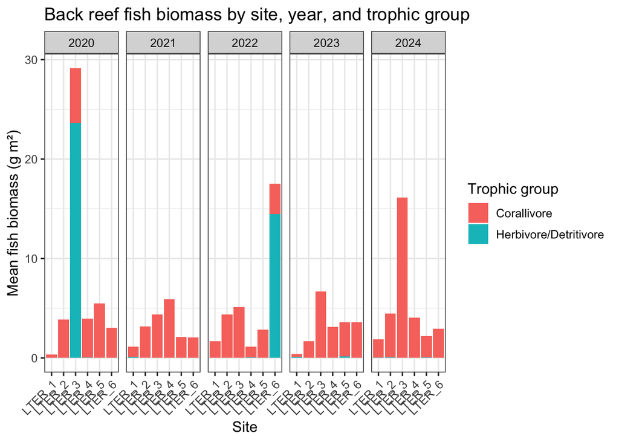

```r
## 2. Plot: stacked biomass by trophic group, per site, per year
ggplot(fish_site_year_troph,
       aes(x = Site,
           y = mean_biomass_g_m2,
           fill = trophic_group)) +
  geom_col() +
  facet_wrap(~ Year, nrow = 1) +
  labs(
    x = "Site",
    y = "Mean fish biomass (g m²)",
    fill = "Trophic group",
    title = "Back reef fish biomass by site, year, and trophic group"
  ) +
  theme_bw(base_size = 12) +
  theme(
    axis.text.x = element_text(angle = 45, hjust = 1)
  )
```

```r
# Now summarise to SITE level across years & transects
fish_backreef_site <- fish_backreef_transect %>%
  group_by(Site, trophic_group) %>%
  summarise(
    mean_biomass_g_m2 = mean(biomass_g_m2, na.rm = TRUE),
    sd_biomass_g_m2   = sd(biomass_g_m2, na.rm = TRUE),
    n_transects       = n(),
    .groups = "drop"
  ) %>%
  # Wide format: separate columns for herbivore / corallivore biomass
  pivot_wider(
    names_from = trophic_group,
    values_from = c(mean_biomass_g_m2, sd_biomass_g_m2, n_transects),
    names_glue = "fish_{trophic_group}_{.value}"
  )

fish_backreef_site
```

```
## # A tibble: 6 × 7
##   Site   fish_Corallivore_mean_b…¹ fish_Herbivore/Detri…² fish_Corallivore_sd_…³
##   <chr>                      <dbl>                  <dbl>                  <dbl>
## 1 LTER_1                      1.08                 0.0789                   1.02
## 2 LTER_2                      3.47                 0.0344                   2.18
## 3 LTER_3                      7.55                23.6                     11.4
## 4 LTER_4                      3.57                 0.0302                   2.89
## 5 LTER_5                      3.20                 0.0923                   2.18
## 6 LTER_6                      2.94                14.5                      1.96
## # ℹ abbreviated names: ¹fish_Corallivore_mean_biomass_g_m2,
## #   ²`fish_Herbivore/Detritivore_mean_biomass_g_m2`,
## #   ³fish_Corallivore_sd_biomass_g_m2
## # ℹ 3 more variables: `fish_Herbivore/Detritivore_sd_biomass_g_m2` <dbl>,
## #   fish_Corallivore_n_transects <int>,
## #   `fish_Herbivore/Detritivore_n_transects` <int>
```

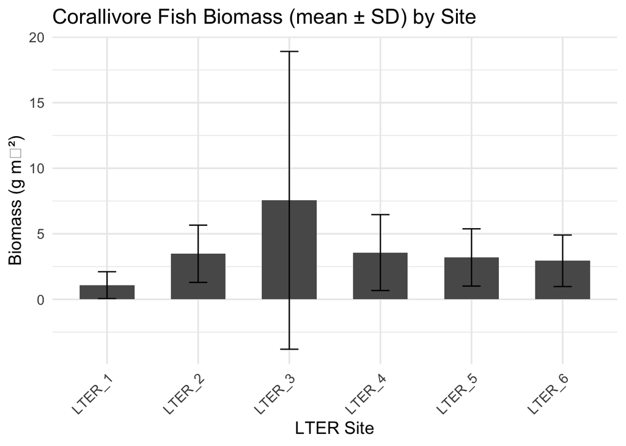

```r
ggplot(fish_backreef_site, aes(x = Site, y = fish_Corallivore_mean_biomass_g_m2)) +
  geom_col(position = position_dodge(width = 0.7), width = 0.6) +
  geom_errorbar(
    aes(ymin = fish_Corallivore_mean_biomass_g_m2 - fish_Corallivore_sd_biomass_g_m2, ymax = fish_Corallivore_mean_biomass_g_m2 + fish_Corallivore_sd_biomass_g_m2),
    width = 0.2,
    position = position_dodge(width = 0.7)
  ) +
  scale_fill_brewer(palette = "Set2") +
  labs(
    title = "Corallivore Fish Biomass (mean ± SD) by Site",
    y = "Biomass (g m⁻²)",
    x = "LTER Site"
  ) +
  theme_minimal(base_size = 14) +
  theme(axis.text.x = element_text(angle = 45, hjust = 1))
```

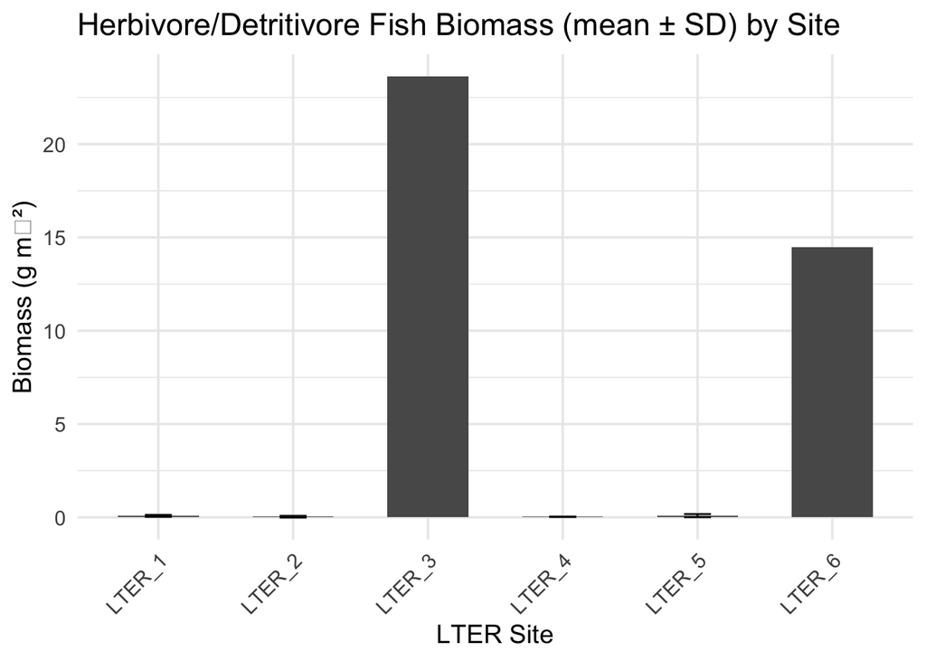

```r
#Fix the fish column names with /
fish_backreef_site <- fish_backreef_site %>%
  rename(
    fish_HerbDet_mean_biomass_g_m2 = `fish_Herbivore/Detritivore_mean_biomass_g_m2`,
    fish_HerbDet_sd_biomass_g_m2   = `fish_Herbivore/Detritivore_sd_biomass_g_m2`,
    fish_HerbDet_n_transects       = `fish_Herbivore/Detritivore_n_transects`
  )

ggplot(fish_backreef_site, aes(x = Site, y = fish_HerbDet_mean_biomass_g_m2)) +
  geom_col(position = position_dodge(width = 0.7), width = 0.6) +
  geom_errorbar(
    aes(ymin = fish_HerbDet_mean_biomass_g_m2 - fish_HerbDet_sd_biomass_g_m2, ymax = fish_HerbDet_mean_biomass_g_m2 + fish_HerbDet_sd_biomass_g_m2),
    width = 0.2,
    position = position_dodge(width = 0.7)
  ) +
  scale_fill_brewer(palette = "Set2") +
  labs(
    title = "Herbivore/Detritivore Fish Biomass (mean ± SD) by Site",
    y = "Biomass (g m⁻²)",
    x = "LTER Site"
  ) +
  theme_minimal(base_size = 14) +
  theme(axis.text.x = element_text(angle = 45, hjust = 1))
```

6.3 Map fish metrics onto coral sites

```r
# sites_benthic must have: site.name, br_site
sites_temp_br <- sites_temp %>%
  left_join(
    sites_benthic %>% select(site.name, br_site),
    by = "site.name"
  )

str(sites_temp_br)
```

```
## tibble [11 × 16] (S3: tbl_df/tbl/data.frame)
##  $ long             : num [1:11] -150 -150 -150 -150 -150 ...
##  $ lat              : num [1:11] -17.6 -17.6 -17.6 -17.5 -17.5 ...
##  $ site.name        : chr [1:11] "S11" "S12" "S14" "S15" ...
##  $ shore            : Factor w/ 3 levels "West","North",..: 3 1 1 1 1 2 2 2 2 3 ...
##  $ temp_site        : chr [1:11] "B20" "B24" "B28" "B31" ...
##  $ temp_long        : num [1:11] -150 -150 -150 -150 -150 ...
##  $ temp_lat         : num [1:11] -17.6 -17.6 -17.6 -17.5 -17.5 ...
##  $ mean_temp_br     : num [1:11] 27.8 27.8 27.9 27.9 27.8 ...
##  $ median_temp_br   : num [1:11] 27.8 27.8 27.8 27.8 27.8 ...
##  $ max_temp_br      : num [1:11] 31.6 31.4 31.7 31.7 31.3 ...
##  $ p95_temp_br      : Named num [1:11] 30.2 30 30.3 30.3 30.3 ...
##   ..- attr(*, "names")= chr [1:11] "95%" "95%" "95%" "95%" ...
##  $ daily_range_br   : num [1:11] 0.918 0.815 0.988 0.956 1.382 ...
##  $ sd_temp_br       : num [1:11] 1.014 1.014 1.014 1.005 0.989 ...
##  $ freq_above_30C_br: num [1:11] 0.0831 0.0525 0.0921 0.1006 0.1043 ...
##  $ dist_to_temp_m   : num [1:11] 375 598 359 215 168 ...
##  $ br_site          : chr [1:11] "LTER_5" "LTER_5" "LTER_5" "LTER_6" ...
```

```r
sites_temp_fish <- sites_temp_br %>%
  left_join(
    fish_backreef_site,
    by = c("br_site" = "Site")
  )

str(sites_temp_fish)
```

```
## tibble [11 × 22] (S3: tbl_df/tbl/data.frame)
##  $ long                              : num [1:11] -150 -150 -150 -150 -150 ...
##  $ lat                               : num [1:11] -17.6 -17.6 -17.6 -17.5 -17.5 ...
##  $ site.name                         : chr [1:11] "S11" "S12" "S14" "S15" ...
##  $ shore                             : Factor w/ 3 levels "West","North",..: 3 1 1 1 1 2 2 2 2 3 ...
##  $ temp_site                         : chr [1:11] "B20" "B24" "B28" "B31" ...
##  $ temp_long                         : num [1:11] -150 -150 -150 -150 -150 ...
##  $ temp_lat                          : num [1:11] -17.6 -17.6 -17.6 -17.5 -17.5 ...
##  $ mean_temp_br                      : num [1:11] 27.8 27.8 27.9 27.9 27.8 ...
##  $ median_temp_br                    : num [1:11] 27.8 27.8 27.8 27.8 27.8 ...
##  $ max_temp_br                       : num [1:11] 31.6 31.4 31.7 31.7 31.3 ...
##  $ p95_temp_br                       : Named num [1:11] 30.2 30 30.3 30.3 30.3 ...
##   ..- attr(*, "names")= chr [1:11] "95%" "95%" "95%" "95%" ...
##  $ daily_range_br                    : num [1:11] 0.918 0.815 0.988 0.956 1.382 ...
##  $ sd_temp_br                        : num [1:11] 1.014 1.014 1.014 1.005 0.989 ...
##  $ freq_above_30C_br                 : num [1:11] 0.0831 0.0525 0.0921 0.1006 0.1043 ...
##  $ dist_to_temp_m                    : num [1:11] 375 598 359 215 168 ...
##  $ br_site                           : chr [1:11] "LTER_5" "LTER_5" "LTER_5" "LTER_6" ...
##  $ fish_Corallivore_mean_biomass_g_m2: num [1:11] 3.2 3.2 3.2 2.94 2.94 ...
##  $ fish_HerbDet_mean_biomass_g_m2    : num [1:11] 0.0923 0.0923 0.0923 14.483 14.483 ...
##  $ fish_Corallivore_sd_biomass_g_m2  : num [1:11] 2.18 2.18 2.18 1.96 1.96 ...
##  $ fish_HerbDet_sd_biomass_g_m2      : num [1:11] 0.0819 0.0819 0.0819 NA NA ...
##  $ fish_Corallivore_n_transects      : int [1:11] 20 20 20 21 21 14 14 19 19 20 ...
##  $ fish_HerbDet_n_transects          : int [1:11] 2 2 2 1 1 3 3 2 2 1 ...
```

```r
sites_fish <- sites_temp_fish %>%
  select(
    site.name, shore, br_site,
    fish_Corallivore_mean_biomass_g_m2,
    fish_HerbDet_mean_biomass_g_m2
  )

str(sites_fish)
```

```
## tibble [11 × 5] (S3: tbl_df/tbl/data.frame)
##  $ site.name                         : chr [1:11] "S11" "S12" "S14" "S15" ...
##  $ shore                             : Factor w/ 3 levels "West","North",..: 3 1 1 1 1 2 2 2 2 3 ...
##  $ br_site                           : chr [1:11] "LTER_5" "LTER_5" "LTER_5" "LTER_6" ...
##  $ fish_Corallivore_mean_biomass_g_m2: num [1:11] 3.2 3.2 3.2 2.94 2.94 ...
##  $ fish_HerbDet_mean_biomass_g_m2    : num [1:11] 0.0923 0.0923 0.0923 14.483 14.483 ...
```

7. Nutrients: Turbinaria N high-resolution, lagoon-wide 7.1 clean import + mapping of high-res Turbinaria CHN

```r
# Package ID: knb-lter-mcr.1047.1 Cataloging System:https://pasta.edirepository.org.
# Data set title: MCR LTER: Coral Reef: Turbinaria CHN from a spatially explicit sampling campaign in lagoons of Moorea, French Polynesia.
# Data set creator:    - Moorea Coral Reef LTER
# Data set creator:  Thomas Adam - Moorea Coral Reef LTER
# Data set creator:  Christian John - University of California, Santa Barbara
# Data set creator:  Deron Burkepile - Moorea Coral Reef LTER
# Metadata Provider:    - Moorea Coral Reef LTER
# Contact:    - Information Manager Moorea Coral Reef LTER  - mcrlter@msi.ucsb.edu

options(HTTPUserAgent = "EDI_CodeGen")

## --------------------------------------------------
## TABLE 1: Site metadata (coords, habitat, distance)
## --------------------------------------------------
url_sites <- "https://pasta.lternet.edu/package/data/eml/knb-lter-mcr/1047/1/45ed57442847daf0fb6a7dbccac56b53"
tmp_sites <- tempfile()
try(download.file(url_sites, tmp_sites,
                  method = "curl",
                  extra  = paste0(' -A "', getOption("HTTPUserAgent"), '"')))
if (is.na(file.size(tmp_sites))) {
  download.file(url_sites, tmp_sites, method = "auto")
}

turbinaria_sites <- read.csv(
  tmp_sites,
  header   = FALSE,
  skip     = 1,
  sep      = ",",
  quote    = '"',
  col.names = c(
    "Site",
    "Longitude",
    "Latitude",
    "Habitat",
    "Island_shore",
    "Distance_from_shore",
    "Distance_from_crest",
    "Watershed_area",
    "Cleared_area"
  ),
  check.names = TRUE,
  stringsAsFactors = FALSE
)

unlink(tmp_sites)

turbinaria_sites <- turbinaria_sites %>%
  mutate(
    Site                = factor(Site),
    Habitat             = factor(Habitat),
    Island_shore        = factor(Island_shore),
    Longitude           = as.numeric(Longitude),
    Latitude            = as.numeric(Latitude),
    Distance_from_shore = as.numeric(Distance_from_shore),
    Distance_from_crest = as.numeric(Distance_from_crest),
    Watershed_area      = as.numeric(Watershed_area),
    Cleared_area        = as.numeric(Cleared_area)
  )

str(turbinaria_sites)
```

```
## 'data.frame':    222 obs. of  9 variables:
##  $ Site               : Factor w/ 222 levels "001","002","003",..: 1 2 3 4 5 6 7 8 9 10 ...
##  $ Longitude          : num  -150 -150 -150 -150 -150 ...
##  $ Latitude           : num  -17.6 -17.6 -17.6 -17.6 -17.6 ...
##  $ Habitat            : Factor w/ 6 levels "Back reef","Bay",..: 3 4 1 3 1 1 3 3 1 4 ...
##  $ Island_shore       : Factor w/ 3 levels "N","SE","SW": 3 3 3 3 3 3 3 3 3 3 ...
##  $ Distance_from_shore: num  174 473 1197 664 1187 ...
##  $ Distance_from_crest: num  850 553 226 905 185 ...
##  $ Watershed_area     : num  0.526 0.526 0.469 0.47 0.521 0.5 0.516 0.508 0.5 0.5 ...
##  $ Cleared_area       : num  0.217 0.217 0.18 0.164 0.139 0.117 0.137 0.176 0.117 0.117 ...
```

```r
## --------------------------------------------------
## TABLE 2: Full CHN measurements (Percent_N, C:N)
## --------------------------------------------------
url_chn <- "https://pasta.lternet.edu/package/data/eml/knb-lter-mcr/1047/1/098ecd51f703743ef38e4db4967778cb"
tmp_chn <- tempfile()
try(download.file(url_chn, tmp_chn,
                  method = "curl",
                  extra  = paste0(' -A "', getOption("HTTPUserAgent"), '"')))
if (is.na(file.size(tmp_chn))) {
  download.file(url_chn, tmp_chn, method = "auto")
}

turbinaria_chn <- read.csv(
  tmp_chn,
  header   = FALSE,
  skip     = 1,
  sep      = ",",
  quote    = '"',
  col.names = c(
    "Site",
    "FieldSeason",
    "Date",
    "Year",
    "Month",
    "Day",
    "Weight_ug",
    "Percent_C",
    "Percent_H",
    "Percent_N",
    "C_to_N_ratio"
  ),
  check.names = TRUE,
  stringsAsFactors = FALSE
)

unlink(tmp_chn)

turbinaria_chn <- turbinaria_chn %>%
  mutate(
    Site        = factor(Site),
    FieldSeason = factor(FieldSeason),
    Date        = as.Date(Date, format = "%Y-%m-%d"),
    Year        = as.integer(Year),
    Month       = as.numeric(Month),
    Day         = as.numeric(Day),
    Weight_ug   = as.numeric(Weight_ug),
    Percent_C   = as.numeric(Percent_C),
    Percent_H   = as.numeric(Percent_H),
    Percent_N   = as.numeric(Percent_N),
    C_to_N_ratio = as.numeric(C_to_N_ratio)
  )

str(turbinaria_chn)
```

```
## 'data.frame':    1003 obs. of  11 variables:
##  $ Site        : Factor w/ 213 levels "001","002","003",..: 22 23 29 56 60 61 65 66 83 85 ...
##  $ FieldSeason : Factor w/ 7 levels "2016-May","2017-April",..: 1 1 1 1 1 1 1 1 1 1 ...
##  $ Date        : Date, format: "2016-05-11" "2016-05-11" ...
##  $ Year        : int  2016 2016 2016 2016 2016 2016 2016 2016 2016 2016 ...
##  $ Month       : num  5 5 5 5 5 5 5 5 5 5 ...
##  $ Day         : num  11 11 11 10 10 10 10 10 12 12 ...
##  $ Weight_ug   : num  2102 2347 2285 2403 2055 ...
##  $ Percent_C   : num  28.4 26.1 28.4 26.9 27.5 ...
##  $ Percent_H   : num  4.02 3.65 4.12 3.82 3.74 3.68 3.47 3.44 3.9 3.57 ...
##  $ Percent_N   : num  0.67 0.7 0.58 0.63 0.71 0.7 0.69 0.76 0.78 0.71 ...
##  $ C_to_N_ratio: num  42.5 37.5 49.2 42.7 38.8 ...
```

7.2 Summarize data and map onto the coral density site

```r
## --------------------------------------------------
## 1. Summarise Turbinaria %N by Turbinaria Site
## --------------------------------------------------

turb_N_site <- turbinaria_chn %>%
  group_by(Site) %>%
  summarise(
    turb_N_mean_pct = mean(Percent_N, na.rm = TRUE),
    turb_N_sd_pct   = sd(Percent_N,   na.rm = TRUE),
    turb_N_n_samples = sum(!is.na(Percent_N)),
    Year_min        = min(Year, na.rm = TRUE),
    Year_max        = max(Year, na.rm = TRUE),
    .groups = "drop"
  ) %>%
  # add coordinates + basic metadata
  left_join(
    turbinaria_sites %>%
      select(
        Site,
        turb_long         = Longitude,
        turb_lat          = Latitude,
        turb_Habitat      = Habitat,
        turb_Island_shore = Island_shore
      ),
    by = "Site"
  ) %>%
  # keep only sites with coordinates and N
  filter(!is.na(turb_long), !is.na(turb_lat), !is.na(turb_N_mean_pct))

## --------------------------------------------------
## 2. Coral sites (S11–S36) from sites_wave
## --------------------------------------------------

coral_sites <- sites_wave %>%
  select(site.name, long, lat, shore) %>%
  distinct() %>%
  filter(!is.na(long), !is.na(lat))

## --------------------------------------------------
## 3. Haversine distance matrix (coral × Turbinaria)
## --------------------------------------------------

# Matrices of lon/lat (in degrees) for geosphere
coral_coords <- as.matrix(coral_sites[, c("long", "lat")])
turb_coords  <- as.matrix(turb_N_site[, c("turb_long", "turb_lat")])

# distHaversine can take vectors or matrices; use outer-style apply
# Build an n_coral × n_turb matrix of distances (m)
dist_mat <- sapply(
  1:nrow(turb_coords),
  function(j) distHaversine(coral_coords, turb_coords[j, ])
)

# dist_mat[i, j] = distance from coral_sites[i, ] to turb_N_site[j, ]

## --------------------------------------------------
## 4. For each coral site, find nearest Turbinaria site
## --------------------------------------------------

# index of nearest Turbinaria site per coral site
nn_index <- max.col(-dist_mat)  # argmin via argmax of negative

# minimum distance in meters
dist_min_m <- dist_mat[cbind(seq_len(nrow(coral_sites)), nn_index)]

## --------------------------------------------------
## 5. Build coral_turb lookup table
## --------------------------------------------------

coral_turb <- coral_sites %>%
  bind_cols(
    turb_N_site[nn_index, c("Site",
                            "turb_N_mean_pct",
                            "turb_N_sd_pct",
                            "turb_N_n_samples")] %>%
      rename(
        turb_site = Site
      )
  ) %>%
  mutate(
    dist_to_turb_m = dist_min_m
  )

# Inspect result
str(coral_turb)
```

```
## tibble [11 × 9] (S3: tbl_df/tbl/data.frame)
##  $ site.name       : chr [1:11] "S11" "S12" "S14" "S15" ...
##  $ long            : num [1:11] -150 -150 -150 -150 -150 ...
##  $ lat             : num [1:11] -17.6 -17.6 -17.6 -17.5 -17.5 ...
##  $ shore           : chr [1:11] "East" "West" "West" "West" ...
##  $ turb_site       : Factor w/ 222 levels "001","002","003",..: 49 12 82 94 113 146 152 183 166 73 ...
##  $ turb_N_mean_pct : num [1:11] 0.566 0.573 0.592 0.588 0.527 ...
##  $ turb_N_sd_pct   : num [1:11] 0.055 0.0513 0.0955 0.0783 0.0565 ...
##  $ turb_N_n_samples: int [1:11] 5 3 5 6 6 6 5 6 6 6 ...
##  $ dist_to_turb_m  : num [1:11] 263 166 241 236 190 ...
```

```r
head(coral_turb)
```

```
## # A tibble: 6 × 9
##   site.name  long   lat shore turb_site turb_N_mean_pct turb_N_sd_pct
##   <chr>     <dbl> <dbl> <chr> <fct>               <dbl>         <dbl>
## 1 S11       -150. -17.6 East  050                 0.566        0.0550
## 2 S12       -150. -17.6 West  012                 0.573        0.0513
## 3 S14       -150. -17.6 West  083                 0.592        0.0955
## 4 S15       -150. -17.5 West  095                 0.588        0.0783
## 5 S18       -150. -17.5 West  114                 0.527        0.0565
## 6 S2        -150. -17.5 North 147                 0.605        0.0650
## # ℹ 2 more variables: turb_N_n_samples <int>, dist_to_turb_m <dbl>
```

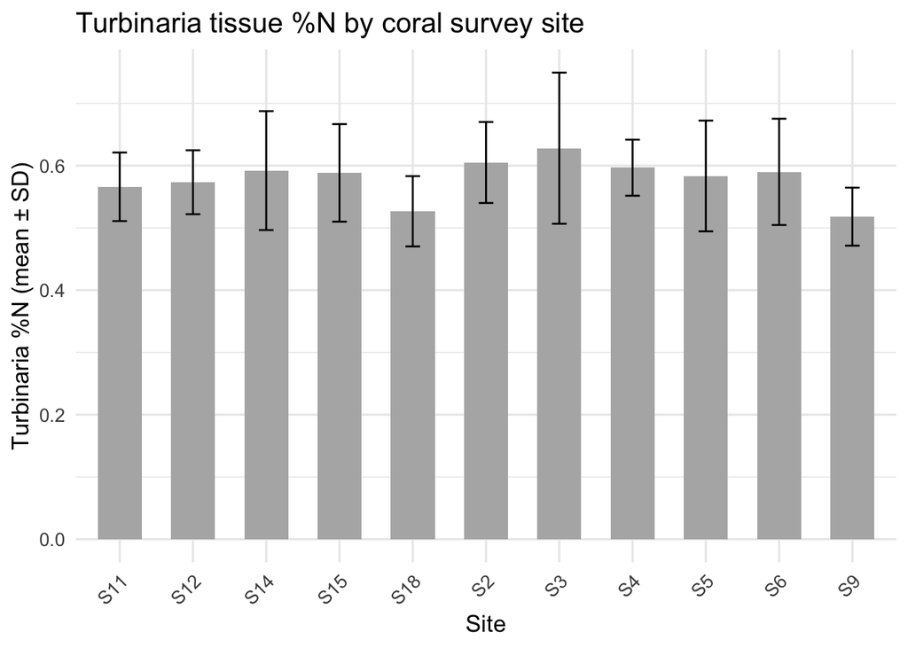

```r
#  barplot: mean ± SD by site
ggplot(coral_turb, aes(x = site.name, y = turb_N_mean_pct)) +
  geom_col(fill = "grey70", width = 0.6) +
  geom_errorbar(
    aes(ymin = turb_N_mean_pct - turb_N_sd_pct,
        ymax = turb_N_mean_pct + turb_N_sd_pct),
    width = 0.2
  ) +
  labs(
    title = "Turbinaria tissue %N by coral survey site",
    x = "Site",
    y = "Turbinaria %N (mean ± SD)"
  ) +
  theme_minimal(base_size = 13) +
  theme(axis.text.x = element_text(angle = 45, hjust = 1))
```

8. fDOM Dissolved Organic Matter 8.1 clean fDOM import

```r
# Package ID: knb-lter-mcr.1049.1 Cataloging System:https://pasta.edirepository.org.
# Data set title: MCR LTER: Coral Reef: Water Column fDOM in lagoons of Moorea, French Polynesia.
# Data set creator:    - Moorea Coral Reef LTER
# Data set creator:  Craig Nelson - University of Hawaiʻi at Mānoa
# Data set creator:  Sean Swift - University of Hawaiʻi at Mānoa
# Metadata Provider:    - Moorea Coral Reef LTER
# Contact:    - Information Manager Moorea Coral Reef LTER  - mcrlter@msi.ucsb.edu

## -------------------------------------------------------------
## fDOM data: site metadata and sample-level observations
## (non-overlapping names, no attach/detach, tidy-friendly)
## -------------------------------------------------------------

options(HTTPUserAgent = "EDI_CodeGen")

library(dplyr)

### 1. fDOM site metadata (coordinates, watershed, etc.) ----

inUrl_fdom_sites  <- "https://pasta.lternet.edu/package/data/eml/knb-lter-mcr/1049/1/45ed57442847daf0fb6a7dbccac56b53"
tmp_fdom_sites    <- tempfile()

try(download.file(
  inUrl_fdom_sites,
  tmp_fdom_sites,
  method = "curl",
  extra  = paste0(' -A "', getOption("HTTPUserAgent"), '"')
))
if (is.na(file.size(tmp_fdom_sites))) {
  download.file(inUrl_fdom_sites, tmp_fdom_sites, method = "auto")
}

fdom_sites_raw <- read.csv(
  tmp_fdom_sites,
  header    = FALSE,
  skip      = 1,
  sep       = ",",
  quote     = '"',
  col.names = c(
    "Site",
    "Longitude",
    "Latitude",
    "Habitat",
    "Island_shore",
    "Distance_from_shore",
    "Distance_from_crest",
    "Watershed_area",
    "Cleared_area"
  ),
  check.names = TRUE
)

unlink(tmp_fdom_sites)

## Basic type cleaning
fdom_sites_raw <- fdom_sites_raw %>%
  mutate(
    Site                = as.factor(Site),
    Habitat             = as.factor(Habitat),
    Island_shore        = as.factor(Island_shore),
    Longitude           = as.numeric(Longitude),
    Latitude            = as.numeric(Latitude),
    Distance_from_shore = as.numeric(Distance_from_shore),
    Distance_from_crest = as.numeric(Distance_from_crest),
    Watershed_area      = as.numeric(Watershed_area),
    Cleared_area        = as.numeric(Cleared_area)
  )

## Namespaced version to avoid clashes with other objects
fdom_sites <- fdom_sites_raw %>%
  rename(
    fdom_site          = Site,
    fdom_long          = Longitude,
    fdom_lat           = Latitude,
    fdom_habitat       = Habitat,
    fdom_shore_cat     = Island_shore,
    fdom_dist_shore_m  = Distance_from_shore,
    fdom_dist_crest_m  = Distance_from_crest,
    fdom_watershed_km2 = Watershed_area,
    fdom_cleared_km2   = Cleared_area
  )

str(fdom_sites)
```

```
## 'data.frame':    222 obs. of  9 variables:
##  $ fdom_site         : Factor w/ 222 levels "001","002","003",..: 1 2 3 4 5 6 7 8 9 10 ...
##  $ fdom_long         : num  -150 -150 -150 -150 -150 ...
##  $ fdom_lat          : num  -17.6 -17.6 -17.6 -17.6 -17.6 ...
##  $ fdom_habitat      : Factor w/ 6 levels "Back reef","Bay",..: 3 4 1 3 1 1 3 3 1 4 ...
##  $ fdom_shore_cat    : Factor w/ 3 levels "N","SE","SW": 3 3 3 3 3 3 3 3 3 3 ...
##  $ fdom_dist_shore_m : num  174 473 1197 664 1187 ...
##  $ fdom_dist_crest_m : num  850 553 226 905 185 ...
##  $ fdom_watershed_km2: num  0.526 0.526 0.469 0.47 0.521 0.5 0.516 0.508 0.5 0.5 ...
##  $ fdom_cleared_km2  : num  0.217 0.217 0.18 0.164 0.139 0.117 0.137 0.176 0.117 0.117 ...
```

```r
### 2. fDOM sample-level data (HIX, FI, components, etc.) ----

inUrl_fdom_obs  <- "https://pasta.lternet.edu/package/data/eml/knb-lter-mcr/1049/1/c2fc28a7d3f0cec75aa163ac646d65be"
tmp_fdom_obs    <- tempfile()

try(download.file(
  inUrl_fdom_obs,
  tmp_fdom_obs,
  method = "curl",
  extra  = paste0(' -A "', getOption("HTTPUserAgent"), '"')
))
if (is.na(file.size(tmp_fdom_obs))) {
  download.file(inUrl_fdom_obs, tmp_fdom_obs, method = "auto")
}

fdom_obs_raw <- read.csv(
  tmp_fdom_obs,
  header    = FALSE,
  skip      = 1,
  sep       = ",",
  quote     = '"',
  col.names = c(
    "Site",
    "FieldSeason",
    "Date",
    "Year",
    "Month",
    "Day",
    "HIX",
    "BIX",
    "M.C",
    "FI",
    "Ultra.Violet.Humic.like",
    "Marine.Humic.like",
    "Visible.Humic.like",
    "Tryptophan.like",
    "Tyrosine.like",
    "Lignin.like"
  ),
  check.names = TRUE
)

unlink(tmp_fdom_obs)

## Basic type cleaning
fdom_obs_raw <- fdom_obs_raw %>%
  mutate(
    Site         = as.factor(Site),
    FieldSeason  = as.factor(FieldSeason),
    Date         = as.Date(Date, format = "%Y-%m-%d"),
    Year         = as.integer(Year),
    Month        = as.integer(Month),
    Day          = as.integer(Day),
    HIX          = as.numeric(HIX),
    BIX          = as.numeric(BIX),
    M.C          = as.numeric(M.C),
    FI           = as.numeric(FI),
    Ultra.Violet.Humic.like = as.numeric(Ultra.Violet.Humic.like),
    Marine.Humic.like       = as.numeric(Marine.Humic.like),
    Visible.Humic.like      = as.numeric(Visible.Humic.like),
    Tryptophan.like         = as.numeric(Tryptophan.like),
    Tyrosine.like           = as.numeric(Tyrosine.like),
    Lignin.like             = as.numeric(Lignin.like)
  )

## Namespaced version
fdom_obs <- fdom_obs_raw %>%
  rename(
    fdom_site          = Site,
    fdom_field_season  = FieldSeason,
    fdom_date          = Date,
    fdom_year          = Year,
    fdom_month         = Month,
    fdom_day           = Day,
    fdom_HIX           = HIX,
    fdom_BIX           = BIX,
    fdom_MC            = M.C,
    fdom_FI            = FI,
    fdom_UV_humic      = Ultra.Violet.Humic.like,
    fdom_marine_humic  = Marine.Humic.like,
    fdom_vis_humic     = Visible.Humic.like,
    fdom_tryptophan    = Tryptophan.like,
    fdom_tyrosine      = Tyrosine.like,
    fdom_lignin        = Lignin.like
  )

str(fdom_obs)
```

```
## 'data.frame':    562 obs. of  16 variables:
##  $ fdom_site        : Factor w/ 203 levels "001","002","003",..: 1 2 3 4 5 6 7 8 9 10 ...
##  $ fdom_field_season: Factor w/ 3 levels "2021-May","2022-April",..: 1 1 1 1 1 1 1 1 1 1 ...
##  $ fdom_date        : Date, format: "2021-05-20" "2021-05-20" ...
##  $ fdom_year        : int  2021 2021 2021 2021 2021 2021 2021 2021 2021 2021 ...
##  $ fdom_month       : int  5 5 5 5 5 5 5 5 5 5 ...
##  $ fdom_day         : int  20 20 20 20 20 20 20 20 20 20 ...
##  $ fdom_HIX         : num  0.822 0.691 0.405 0.492 0.619 ...
##  $ fdom_BIX         : num  0.765 0.824 0.918 0.739 1.03 ...
##  $ fdom_MC          : num  1.22 1.51 1.83 1.6 1.45 ...
##  $ fdom_FI          : num  1.8 1.81 1.78 1.67 1.69 ...
##  $ fdom_UV_humic    : num  0.00993 0.00603 0.00679 0.00705 0.00911 ...
##  $ fdom_marine_humic: num  0.01113 0.00719 0.00922 0.00866 0.01205 ...
##  $ fdom_vis_humic   : num  0.00913 0.00475 0.00505 0.0054 0.00829 ...
##  $ fdom_tryptophan  : num  0.022 0.0125 0.0257 0.0221 0.0326 ...
##  $ fdom_tyrosine    : num  0.02242 0.00737 0.02171 0.02021 0.02228 ...
##  $ fdom_lignin      : num  0.0171 0.0117 0.0107 0.0235 0.0131 ...
```

```r
## Recalculate MC for issue in code of original paper.


fdom_obs <- fdom_obs %>%
  mutate(fdom_MC_corr = fdom_marine_humic/fdom_vis_humic)
```

8.2 Map fDOM to coral density sites

```r
## ------------------------------------------------------------
## 1. Summarise fDOM metrics per fDOM station
## ------------------------------------------------------------

fdom_site_summary <- fdom_obs %>%
  group_by(fdom_site) %>%
  summarise(
    fdom_HIX_mean          = mean(fdom_HIX, na.rm = TRUE),
    fdom_BIX_mean          = mean(fdom_BIX, na.rm = TRUE),
    fdom_MC_mean           = mean(fdom_MC,  na.rm = TRUE),
    fdom_MC_corr_mean      = mean(fdom_MC_corr,  na.rm = TRUE),
    fdom_FI_mean           = mean(fdom_FI,  na.rm = TRUE),
    fdom_UV_humic_mean     = mean(fdom_UV_humic,     na.rm = TRUE),
    fdom_marine_humic_mean = mean(fdom_marine_humic, na.rm = TRUE),
    fdom_vis_humic_mean    = mean(fdom_vis_humic,    na.rm = TRUE),
    fdom_tryptophan_mean   = mean(fdom_tryptophan,   na.rm = TRUE),
    fdom_tyrosine_mean     = mean(fdom_tyrosine,     na.rm = TRUE),
    fdom_lignin_mean       = mean(fdom_lignin,       na.rm = TRUE),
    fdom_n_samples         = dplyr::n(),
    .groups = "drop"
  )

## Attach coordinates + habitat info to those summaries
fdom_sites_full <- fdom_sites %>%
  inner_join(fdom_site_summary, by = "fdom_site")

## ------------------------------------------------------------
## 2. Extract unique coral-density sites with coords
## ------------------------------------------------------------

ph_sites <- sites %>%
  select(site.name, shore, long, lat) %>%
  distinct()

## ------------------------------------------------------------
## 3. Nearest-neighbor mapping: PH sites -> fDOM stations
## ------------------------------------------------------------

# All pairwise combinations
ph_fdom_pairs <- tidyr::crossing(
  ph_sites %>% rename(ph_site = site.name),
  fdom_sites_full
)

# Great-circle distance in meters
ph_fdom_pairs <- ph_fdom_pairs %>%
  mutate(
    dist_to_fdom_m = distHaversine(
      cbind(long, lat),
      cbind(fdom_long, fdom_lat)
    )
  )

# For each PH site, keep the closest fDOM station
sites_fdom <- ph_fdom_pairs %>%
  group_by(ph_site) %>%
  slice_min(dist_to_fdom_m, n = 1, with_ties = FALSE) %>%
  ungroup() %>%
  rename(site.name = ph_site) %>%
  select(
    site.name, shore, long, lat,
    fdom_site, fdom_long, fdom_lat, fdom_habitat, fdom_shore_cat,
    dist_to_fdom_m,
    fdom_HIX_mean, fdom_BIX_mean, fdom_MC_mean, fdom_MC_corr_mean, fdom_FI_mean,
    fdom_UV_humic_mean, fdom_marine_humic_mean, fdom_vis_humic_mean,
    fdom_tryptophan_mean, fdom_tyrosine_mean, fdom_lignin_mean,
    fdom_n_samples
  )

## Quick check
print(sites_fdom)
```

```
## # A tibble: 11 × 22
##    site.name shore  long   lat fdom_site fdom_long fdom_lat fdom_habitat
##    <chr>     <fct> <dbl> <dbl> <fct>         <dbl>    <dbl> <fct>
##  1 S11       East  -150. -17.6 050           -150.    -17.6 Back reef
##  2 S12       West  -150. -17.6 012           -150.    -17.6 Reef pass
##  3 S14       West  -150. -17.6 083           -150.    -17.6 Back reef
##  4 S15       West  -150. -17.5 095           -150.    -17.5 Back reef
##  5 S18       West  -150. -17.5 114           -150.    -17.5 Back reef
##  6 S2        North -150. -17.5 147           -150.    -17.5 Back reef
##  7 S3        North -150. -17.5 153           -150.    -17.5 Back reef
##  8 S4        North -150. -17.5 185           -150.    -17.5 Mid lagoon
##  9 S5        North -150. -17.5 167           -150.    -17.5 Reef pass
## 10 S6        East  -150. -17.5 074           -150.    -17.5 Back reef
## 11 S9        East  -150. -17.6 043           -150.    -17.6 Back reef
## # ℹ 14 more variables: fdom_shore_cat <fct>, dist_to_fdom_m <dbl>,
## #   fdom_HIX_mean <dbl>, fdom_BIX_mean <dbl>, fdom_MC_mean <dbl>,
## #   fdom_MC_corr_mean <dbl>, fdom_FI_mean <dbl>, fdom_UV_humic_mean <dbl>,
## #   fdom_marine_humic_mean <dbl>, fdom_vis_humic_mean <dbl>,
## #   fdom_tryptophan_mean <dbl>, fdom_tyrosine_mean <dbl>,
## #   fdom_lignin_mean <dbl>, fdom_n_samples <int>
```

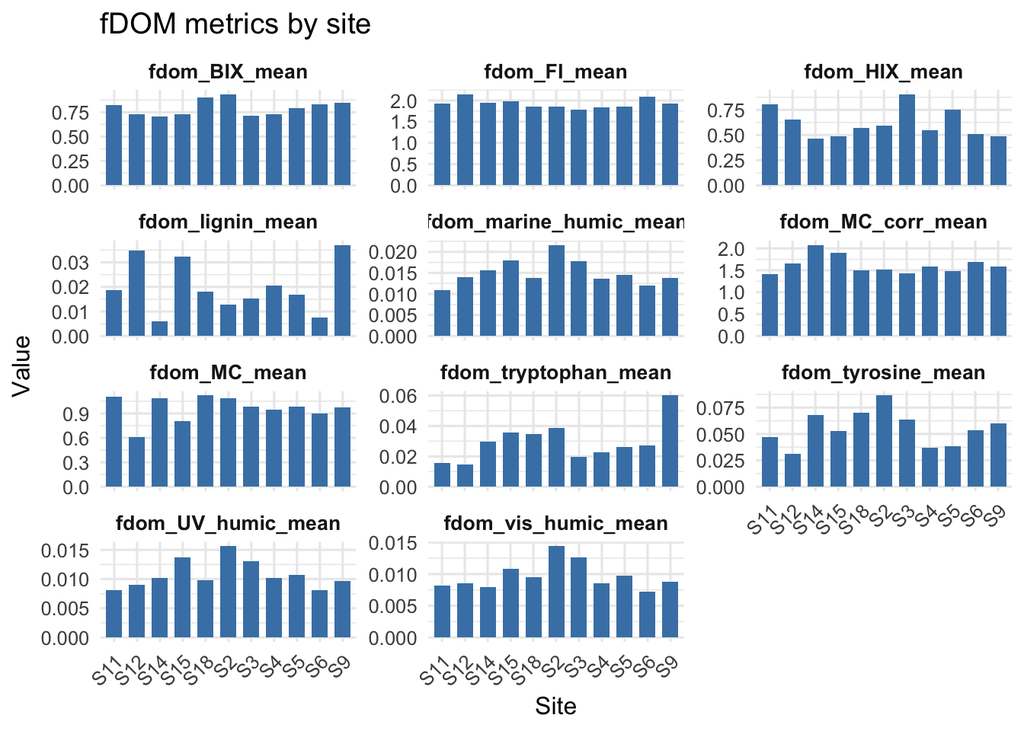

```r
# Select only the fDOM metrics (exclude n_samples)
fdom_metrics <- sites_fdom %>%
  select(site.name,
         starts_with("fdom_")) %>%
  select(-fdom_site) %>%
  select(-fdom_long)%>%
  select(-fdom_lat)%>%
  select(-fdom_habitat)%>%
  select(-fdom_shore_cat)%>%
  select(-fdom_n_samples)

# Pivot longer
fdom_long <- fdom_metrics %>%
  pivot_longer(
    cols = -site.name,
    names_to = "metric",
    values_to = "value"
  )

# Plot faceted
ggplot(fdom_long, aes(x = site.name, y = value)) +
  geom_col(fill = "steelblue", width = 0.7) +
  facet_wrap(~ metric, scales = "free_y", ncol = 3) +
  labs(
    title = "fDOM metrics by site",
    x = "Site",
    y = "Value"
  ) +
  theme_minimal(base_size = 12) +
  theme(
    axis.text.x = element_text(angle = 45, hjust = 1),
    strip.text = element_text(size = 10, face = "bold")
  )
```

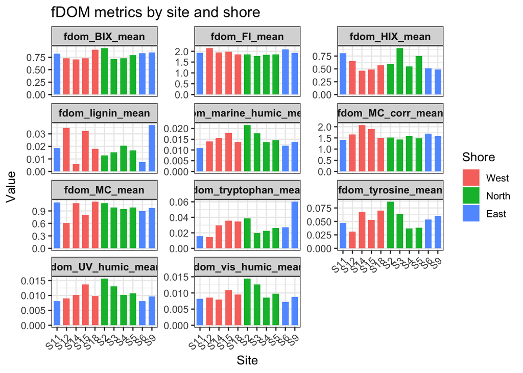

```r
fdom_long2 <- sites_fdom %>%
  select(site.name,shore,
         starts_with("fdom_")) %>%
  select(-fdom_site) %>%
  select(-fdom_long)%>%
  select(-fdom_lat)%>%
  select(-fdom_habitat)%>%
  select(-fdom_shore_cat)%>%
  select(-fdom_n_samples)  %>%
  pivot_longer(
    cols = -c(site.name, shore),
    names_to = "metric",
    values_to = "value"
  )

ggplot(fdom_long2, aes(x = site.name, y = value, fill = shore)) +
  geom_col(position = "dodge", width = 0.7) +
  facet_wrap(~ metric, scales = "free_y", ncol = 3) +
  labs(
    title = "fDOM metrics by site and shore",
    x = "Site",
    y = "Value",
    fill = "Shore"
  ) +
  theme_bw(base_size = 12) +
  theme(
    axis.text.x = element_text(angle = 45, hjust = 1),
    strip.text = element_text(size = 10, face = "bold")
  )
```

9. Seawater Chemistry data (N,Si,P) 9.1 Import Seawater Chemistry data

```r
# Package ID: knb-lter-mcr.1048.1 Cataloging System:https://pasta.edirepository.org.
# Data set title: MCR LTER: Coral Reef: Water Column nutrient data in lagoons of Moorea, French Polynesia.
# Data set creator:    - Moorea Coral Reef LTER
# Data set creator:  Thomas Adam - Moorea Coral Reef LTER
# Data set creator:  Christian John - University of California, Santa Barbara
# Data set creator:  Rebecca Vega Thurber - University of California, Santa Barbara
# Data set creator:  Deron Burkepile - Moorea Coral Reef LTER
# Metadata Provider:   Information Manager - Moorea Coral Reef LTER
# Contact:    - Information Manager Moorea Coral Reef LTER  - mcrlter@msi.ucsb.edu

## ============================================================
## 1. IMPORT knb-lter-mcr.1048.1 (water-column nutrients)
##    - Site metadata  (table 1)
##    - Nutrient data  (table 2)
## ============================================================

options(HTTPUserAgent = "EDI_CodeGen")

## ---- 1a. Site metadata ----
nut_site_url  <- "https://pasta.lternet.edu/package/data/eml/knb-lter-mcr/1048/1/45ed57442847daf0fb6a7dbccac56b53"
nut_site_tmp  <- tempfile()

try(download.file(nut_site_url, nut_site_tmp, method = "curl",
                  extra = paste0(' -A "', getOption("HTTPUserAgent"), '"')))
if (is.na(file.size(nut_site_tmp))) {
  download.file(nut_site_url, nut_site_tmp, method = "auto")
}

nut_sites_raw <- read.csv(
  nut_site_tmp,
  header    = FALSE,
  skip      = 1,
  sep       = ",",
  quote     = '"',
  col.names = c(
    "Site",
    "Longitude",
    "Latitude",
    "Habitat",
    "Island_shore",
    "Distance_from_shore",
    "Distance_from_crest",
    "Watershed_area",
    "Cleared_area"
  ),
  check.names = TRUE,
  stringsAsFactors = FALSE
)

unlink(nut_site_tmp)

# Basic type cleanup & rename with non-overlapping names
nut_sites <- nut_sites_raw %>%
  mutate(
    Site              = factor(Site),
    Habitat           = factor(Habitat),
    Island_shore      = factor(Island_shore),
    Longitude         = as.numeric(Longitude),
    Latitude          = as.numeric(Latitude),
    Distance_from_shore  = as.numeric(Distance_from_shore),
    Distance_from_crest  = as.numeric(Distance_from_crest),
    Watershed_area       = as.numeric(Watershed_area),
    Cleared_area         = as.numeric(Cleared_area)
  ) %>%
  rename(
    nut_site_id             = Site,
    nut_long                = Longitude,
    nut_lat                 = Latitude,
    nut_habitat             = Habitat,
    nut_island_shore        = Island_shore,
    nut_dist_from_shore_m   = Distance_from_shore,
    nut_dist_from_crest_m   = Distance_from_crest,
    nut_watershed_area_km2  = Watershed_area,
    nut_cleared_area_km2    = Cleared_area
  )

## ---- 1b. Nutrient measurements ----
nut_data_url <- "https://pasta.lternet.edu/package/data/eml/knb-lter-mcr/1048/1/7c05cc39e4f71d6f49e0b0d592728e16"
nut_data_tmp <- tempfile()

try(download.file(nut_data_url, nut_data_tmp, method = "curl",
                  extra = paste0(' -A "', getOption("HTTPUserAgent"), '"')))
if (is.na(file.size(nut_data_tmp))) {
  download.file(nut_data_url, nut_data_tmp, method = "auto")
}

nut_samples_raw <- read.csv(
  nut_data_tmp,
  header    = FALSE,
  skip      = 1,
  sep       = ",",
  quote     = '"',
  col.names = c(
    "Site",
    "FieldSeason",
    "Date",
    "Year",
    "Month",
    "Day",
    "Phosphate",
    "Silicate",
    "Nitrite_plus_Nitrate",
    "Ammonia",
    "Notes"
  ),
  check.names = TRUE,
  stringsAsFactors = FALSE
)

unlink(nut_data_tmp)

# Parse dates & clean types, then rename columns
nut_samples <- nut_samples_raw %>%
  mutate(
    Site        = factor(Site),
    FieldSeason = factor(FieldSeason),
    Date        = as.Date(Date, format = "%Y-%m-%d"),
    Year        = as.integer(Year),
    Month       = as.integer(Month),
    Day         = as.integer(Day),
    Phosphate   = as.numeric(Phosphate),
    Silicate    = as.numeric(Silicate),
    Nitrite_plus_Nitrate = as.numeric(Nitrite_plus_Nitrate),
    Ammonia     = as.numeric(Ammonia),
    N_P         = as.numeric(Nitrite_plus_Nitrate)/as.numeric(Phosphate),
    Notes       = if (!is.null(Notes)) factor(Notes) else NULL
  ) %>%
  rename(
    nut_site_id    = Site,
    nut_season     = FieldSeason,
    nut_date       = Date,
    nut_PO4_uM     = Phosphate,
    nut_SiO4_uM    = Silicate,
    nut_NOx_uM     = Nitrite_plus_Nitrate,
    nut_NH4_uM     = Ammonia,
    nut_N_P        = N_P
  )

## ============================================================
## 2. SITE-LEVEL MEAN NUTRIENTS
## ============================================================

nut_site_means <- nut_samples %>%
  group_by(nut_site_id) %>%
  summarise(
    nut_PO4_mean_uM  = mean(nut_PO4_uM,  na.rm = TRUE),
    nut_SiO4_mean_uM = mean(nut_SiO4_uM, na.rm = TRUE),
    nut_NOx_mean_uM  = mean(nut_NOx_uM,  na.rm = TRUE),
    nut_NH4_mean_uM  = mean(nut_NH4_uM,  na.rm = TRUE),
    nut_N_P_mean = mean(nut_N_P,  na.rm = TRUE),
    nut_n_samples    = dplyr::n(),
    .groups = "drop"
  )

nut_sites_summary <- nut_site_means %>%
  left_join(
    nut_sites %>%
      select(
        nut_site_id,
        nut_long,
        nut_lat,
        nut_habitat,
        nut_island_shore,
        nut_dist_from_shore_m,
        nut_dist_from_crest_m,
        nut_watershed_area_km2,
        nut_cleared_area_km2
      ),
    by = "nut_site_id"
  )
```

9.2 clean and map data to coral sites

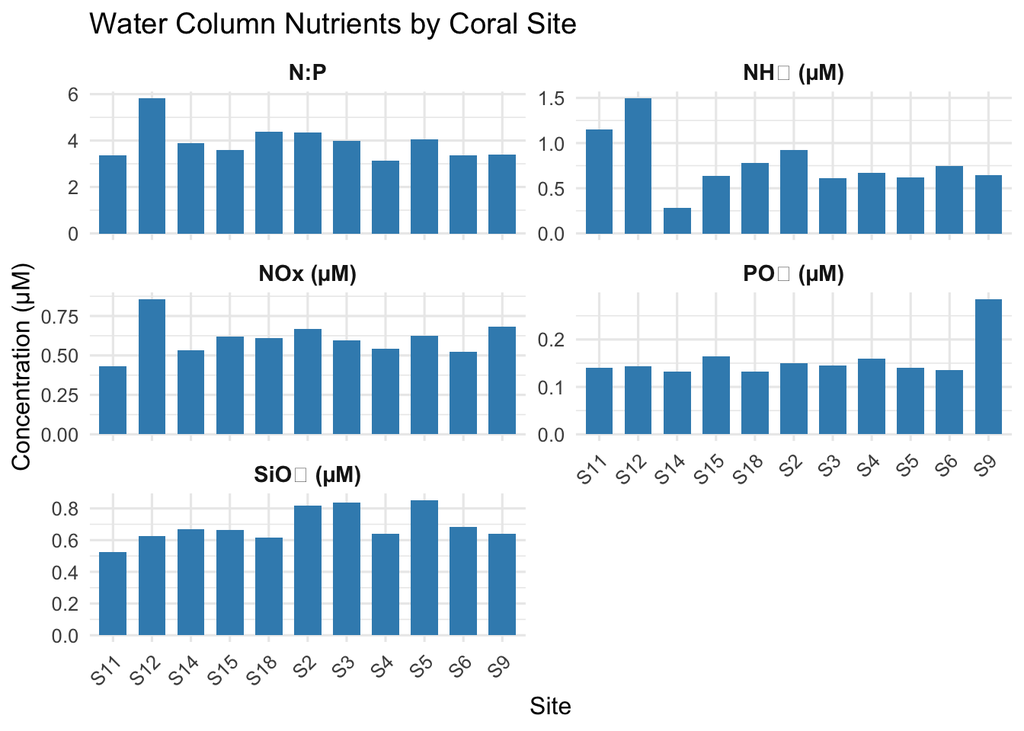

```r
## ============================================================
## 3. NEAREST–NEIGHBOUR MAP: NUTRIENT SITES → CORAL SITES
## ============================================================

# Coral sites from your existing env table
coral_sites <- sites %>%
  select(site.name, long, lat) %>%
  mutate(
    long = as.numeric(long),
    lat  = as.numeric(lat)
  )

coral_coords <- as.matrix(coral_sites[, c("long", "lat")])
nut_coords   <- as.matrix(nut_sites_summary[, c("nut_long", "nut_lat")])

# Index of nearest nutrient site for each coral site
nearest_idx_nut <- apply(coral_coords, 1, function(x) {
  dists_m <- distHaversine(x, nut_coords)
  which.min(dists_m)
})

# Actual distances (m)
nearest_dist_nut_m <- sapply(seq_len(nrow(coral_coords)), function(i) {
  distHaversine(coral_coords[i, ], nut_coords[nearest_idx_nut[i], ])
})

# Coral × nutrient table with mapped values
nut_by_coral <- coral_sites %>%
  mutate(
    nut_site_id_near        = nut_sites_summary$nut_site_id[nearest_idx_nut],
    nut_PO4_mean_uM         = nut_sites_summary$nut_PO4_mean_uM[nearest_idx_nut],
    nut_SiO4_mean_uM        = nut_sites_summary$nut_SiO4_mean_uM[nearest_idx_nut],
    nut_NOx_mean_uM         = nut_sites_summary$nut_NOx_mean_uM[nearest_idx_nut],
    nut_NH4_mean_uM         = nut_sites_summary$nut_NH4_mean_uM[nearest_idx_nut],
    nut_N_P_mean            = nut_sites_summary$nut_N_P_mean[nearest_idx_nut],
    nut_n_samples           = nut_sites_summary$nut_n_samples[nearest_idx_nut],
    nut_habitat_near        = nut_sites_summary$nut_habitat[nearest_idx_nut],
    nut_island_shore_near   = nut_sites_summary$nut_island_shore[nearest_idx_nut],
    dist_to_nut_site_m      = nearest_dist_nut_m
  )

nut_long <- nut_by_coral %>%
  select(site.name,
         nut_PO4_mean_uM,
         nut_SiO4_mean_uM,
         nut_NOx_mean_uM,
         nut_NH4_mean_uM,
         nut_N_P_mean) %>%
  pivot_longer(
    cols = starts_with("nut_"),
    names_to = "nutrient",
    values_to = "value"
  ) %>%
  mutate(nutrient = recode(nutrient,
                           nut_PO4_mean_uM = "PO₄ (µM)",
                           nut_SiO4_mean_uM = "SiO₄ (µM)",
                           nut_NOx_mean_uM = "NOx (µM)",
                           nut_NH4_mean_uM = "NH₄ (µM)",
                           nut_N_P_mean = "N:P"))

ggplot(nut_long, aes(x = site.name, y = value)) +
  geom_col(fill = "#3C8DBC", width = 0.7) +
  facet_wrap(~ nutrient, scales = "free_y", ncol = 2) +
  labs(
    title = "Water Column Nutrients by Coral Site",
    x = "Site",
    y = "Concentration (µM)"
  ) +
  theme_minimal(base_size = 12) +
  theme(
    strip.text = element_text(face = "bold", size = 11),
    axis.text.x = element_text(angle = 45, hjust = 1))
```

Recruitment recruitment only at LTER1–2 (North), same for all PH sites → no spatial variation, so do not include it in X for this site-level JSDM. It can be used in interpretation only for temporal patterns that would assume equal recruitment around the island.

10. Build the predictor matrix X for boral

10.1 Join the environmental dataset

```r
#Start from temperature table (has long, lat, shore, temp metrics)
sites_env_full <- sites_temp %>%

  # ---- Add waves ----
  left_join(
    sites_wave %>%
      select(
        site.name,
        wave_P_mean = P_mean,
        wave_P_p95  = P_p95,
        wave_P_max  = P_max,
        wave_P_sd   = P_sd
      ),
    by = "site.name"
  ) %>%

  # ---- Add benthic cover (backreef) ----
  left_join(
    sites_benthic %>%
      select(
        site.name,
        br_site,
        br_long,
        br_lat,
        coral_cover_br,
        macroalgae_cover_br,
        ctb_cover_br,
        sand_cover_br,
        millepora_cover_br,
        dist_to_br_m
      ),
    by = "site.name"
  ) %>%

  # ---- Add fish biomass (backreef) ----
  left_join(
    sites_fish %>%
      select(
        site.name,
        fish_Corallivore_mean_biomass_g_m2,
        fish_HerbDet_mean_biomass_g_m2
      ),
    by = "site.name"
  ) %>%

  # ---- Add high spatial resolution nutrients (Turbinaria CHN) ----
  left_join(
    coral_turb %>%
      select(
        site.name,
        turb_N_mean_pct,
        turb_N_sd_pct,
        turb_N_n_samples
      ),
    by = "site.name"
  ) %>%

  # ---- Add fDOM ----
  left_join(
    sites_fdom %>%
      select(
        site.name,
        fdom_HIX_mean,
        fdom_BIX_mean,
        fdom_MC_corr_mean,
        fdom_FI_mean
      ),
    by = "site.name"
  ) %>%

  # ---- Add seawater chemistry ----
  left_join(
    nut_by_coral %>%
      select(
        site.name,
        nut_SiO4_mean_uM,
        nut_N_P_mean,
        nut_n_samples
      ),
    by = "site.name"
  )


# Have a look
glimpse(sites_env_full)
```

```
## Rows: 11
## Columns: 40
## $ long                               <dbl> -149.8045, -149.8478, -149.8838, -1…
## $ lat                                <dbl> -17.60277, -17.59509, -17.56501, -1…
## $ site.name                          <chr> "S11", "S12", "S14", "S15", "S18", …
## $ shore                              <fct> East, West, West, West, West, North…
## $ temp_site                          <chr> "B20", "B24", "B28", "B31", "B35", …
## $ temp_long                          <dbl> -149.808, -149.853, -149.885, -149.…
## $ temp_lat                           <dbl> -17.603, -17.593, -17.562, -17.545,…
## $ mean_temp_br                       <dbl> 27.81810, 27.78367, 27.85061, 27.88…
## $ median_temp_br                     <dbl> 27.77305, 27.76398, 27.83105, 27.83…
## $ max_temp_br                        <dbl> 31.5853, 31.4444, 31.6596, 31.7281,…
## $ p95_temp_br                        <dbl> 30.23135, 30.01249, 30.26334, 30.32…
## $ daily_range_br                     <dbl> 0.9182290, 0.8153256, 0.9875805, 0.…
## $ sd_temp_br                         <dbl> 1.0139386, 1.0139417, 1.0135165, 1.…
```

[output cut: 27 more lines]

10.2 Decide which variables to keep as predictors

```r
# colnames(sites_env_full)


env_predictors_raw <- sites_env_full %>%
  select(
    site.name,
    max_temp_br,
    daily_range_br,
    wave_P_mean,
    coral_cover_br,
    ctb_cover_br,
    sand_cover_br,
    fish_Corallivore_mean_biomass_g_m2,
    fish_HerbDet_mean_biomass_g_m2,
    turb_N_mean_pct,
    fdom_HIX_mean,
    fdom_BIX_mean,
    fdom_MC_corr_mean,
    nut_SiO4_mean_uM,
    nut_N_P_mean
  )

env_vars <- c(
    "max_temp_br",
    "daily_range_br",
    "wave_P_mean",
    "coral_cover_br",
    #"macroalgae_cover_br",
    "ctb_cover_br",
    "sand_cover_br",
    "fish_Corallivore_mean_biomass_g_m2",
    "fish_HerbDet_mean_biomass_g_m2",
    "turb_N_mean_pct",
    "fdom_HIX_mean",
    "fdom_BIX_mean",
    "fdom_MC_corr_mean",
    "nut_SiO4_mean_uM",
    "nut_N_P_mean"
  )
```

10.3 Scale the predictors for modeling

```r
# numeric-only matrix for scaling
X_env <- env_predictors_raw %>%
  select(-site.name) %>%
  scale() %>%
  as.data.frame()

# Add site names back for clarity
X_env <- cbind(site = env_predictors_raw$site.name, X_env)

# Look at scaled matrix
X_env
```

```
##    site max_temp_br daily_range_br wave_P_mean coral_cover_br ctb_cover_br
## 1   S11   1.0362972      0.3135215  0.03832737      0.3159985   -1.0120531
## 2   S12   0.6628505     -0.1653121  1.10332243      0.3159985   -1.0120531
## 3   S14   1.2332248      0.6362302  1.10332243      0.3159985   -1.0120531
## 4   S15   1.4147798      0.4883957  1.10332243      0.7226309    0.8330195
## 5   S18   0.2204924      2.4718853  1.10332243      0.7226309    0.8330195
## 6    S2  -0.6318885     -0.5587018 -1.13206796     -0.7667068    1.3276375
## 7    S3  -0.1754831     -0.8278897 -1.13206796     -0.7667068    1.3276375
## 8    S4  -0.9801561     -0.2743203 -1.13206796     -1.4441239    0.2731813
## 9    S5  -1.7024005     -0.2135952 -1.13206796     -1.4441239    0.2731813
## 10   S6  -0.3872531     -0.5790403  0.03832737      0.2229476   -0.6094288
## 11   S9  -0.6904632     -1.2911734  0.03832737      1.8054563   -1.2220884
##    sand_cover_br fish_Corallivore_mean_biomass_g_m2
## 1      1.3752111                        -0.02988432
## 2      1.3752111                        -0.02988432
```

[output cut: 33 more lines]

```r
# Check for missing values (JSDMs cannot handle NAs without imputation)
colSums(is.na(X_env))
```

```
##                               site                        max_temp_br
##                                  0                                  0
##                     daily_range_br                        wave_P_mean
##                                  0                                  0
##                     coral_cover_br                       ctb_cover_br
##                                  0                                  0
##                      sand_cover_br fish_Corallivore_mean_biomass_g_m2
##                                  0                                  0
##     fish_HerbDet_mean_biomass_g_m2                    turb_N_mean_pct
##                                  0                                  0
##                      fdom_HIX_mean                      fdom_BIX_mean
##                                  0                                  0
##                  fdom_MC_corr_mean                   nut_SiO4_mean_uM
##                                  0                                  0
##                       nut_N_P_mean
##                                  0
```

```r
# Check distributions
summary(env_predictors_raw)
```

```
##   site.name          max_temp_br    daily_range_br    wave_P_mean
##  Length:11          Min.   :30.55   Min.   :0.5734   Min.   : 4.843
##  Class :character   1st Qu.:30.94   1st Qu.:0.7286   1st Qu.: 4.843
##  Mode  :character   Median :31.13   Median :0.8049   Median : 9.158
##                     Mean   :31.19   Mean   :0.8509   Mean   : 9.017
##                     3rd Qu.:31.51   3rd Qu.:0.9370   3rd Qu.:13.084
##                     Max.   :31.73   Max.   :1.3821   Max.   :13.084
##  coral_cover_br   ctb_cover_br   sand_cover_br
##  Min.   :11.19   Min.   :35.25   Min.   :18.44
##  1st Qu.:16.52   1st Qu.:36.74   1st Qu.:19.83
##  Median :25.05   Median :45.84   Median :23.77
##  Mean   :22.56   Mean   :43.90   Mean   :25.03
##  3rd Qu.:26.65   3rd Qu.:49.80   3rd Qu.:31.06
##  Max.   :36.77   Max.   :53.30   Max.   :33.54
##  fish_Corallivore_mean_biomass_g_m2 fish_HerbDet_mean_biomass_g_m2
##  Min.   :1.082                      Min.   : 0.03020
##  1st Qu.:2.940                      1st Qu.: 0.05663
##  Median :3.195                      Median : 0.09230
##  Mean   :3.245                      Mean   : 4.83062
##  3rd Qu.:3.475                      3rd Qu.: 7.28765
##  Max.   :7.552                      Max.   :23.63720
##  turb_N_mean_pct  fdom_HIX_mean    fdom_BIX_mean    fdom_MC_corr_mean
##  Min.   :0.5180   Min.   :0.4655   Min.   :0.7039   Min.   :1.405
##  1st Qu.:0.5697   1st Qu.:0.4960   1st Qu.:0.7294   1st Qu.:1.493
##  Median :0.5883   Median :0.5696   Median :0.7947   Median :1.583
##  Mean   :0.5788   Mean   :0.6156   Mean   :0.7941   Mean   :1.620
##  3rd Qu.:0.5943   3rd Qu.:0.7036   3rd Qu.:0.8373   3rd Qu.:1.667
##  Max.   :0.6280   Max.   :0.9059   Max.   :0.9353   Max.   :2.080
##  nut_SiO4_mean_uM  nut_N_P_mean
##  Min.   :0.5250   Min.   :3.140
##  1st Qu.:0.6333   1st Qu.:3.387
##  Median :0.6650   Median :3.887
##  Mean   :0.6881   Mean   :3.937
##  3rd Qu.:0.7512   3rd Qu.:4.197
##  Max.   :0.8525   Max.   :5.824
```

```r
# Check correlations if worried about collinearity
cor(env_predictors_raw %>% select(-site.name), use = "pairwise.complete.obs")
```

```
##                                    max_temp_br daily_range_br wave_P_mean
## max_temp_br                         1.00000000     0.44825053   0.7845463
## daily_range_br                      0.44825053     1.00000000   0.5848124
## wave_P_mean                         0.78454632     0.58481243   1.0000000
## coral_cover_br                      0.52683465     0.16945390   0.7387362
## ctb_cover_br                       -0.23304139     0.16287090  -0.4128521
## sand_cover_br                       0.41747764     0.04529447   0.4112665
## fish_Corallivore_mean_biomass_g_m2 -0.08352825    -0.05729799   0.2240856
## fish_HerbDet_mean_biomass_g_m2      0.17215465     0.34249982   0.3863225
## turb_N_mean_pct                    -0.03525107    -0.33460780  -0.4689926
## fdom_HIX_mean                      -0.16533474    -0.15684922  -0.4854098
## fdom_BIX_mean                      -0.30647469     0.14383239  -0.1343043
## fdom_MC_corr_mean                   0.53249368     0.15448057   0.6045833
## nut_SiO4_mean_uM                   -0.56987366    -0.38409720  -0.6295419
## nut_N_P_mean                        0.15021273     0.17999786   0.3108646
##                                    coral_cover_br ctb_cover_br sand_cover_br
## max_temp_br                          0.5268346505  -0.23304139    0.41747764
## daily_range_br                       0.1694538980   0.16287090    0.04529447
## wave_P_mean                          0.7387362049  -0.41285215    0.41126652
## coral_cover_br                       1.0000000000  -0.49226210    0.15795373
## ctb_cover_br                        -0.4922620977   1.00000000   -0.82837797
## sand_cover_br                        0.1579537348  -0.82837797    1.00000000
## fish_Corallivore_mean_biomass_g_m2   0.2203916731  -0.53449485    0.42440488
## fish_HerbDet_mean_biomass_g_m2       0.3075270434   0.11342583   -0.12477766
## turb_N_mean_pct                     -0.7110767109   0.44351144   -0.06389518
## fdom_HIX_mean                       -0.4620541287   0.26087438   -0.03678845
## fdom_BIX_mean                        0.1825580841   0.16965776   -0.32434437
## fdom_MC_corr_mean                    0.3129986872  -0.28887746    0.31456665
## nut_SiO4_mean_uM                    -0.5953168183   0.61006877   -0.53806386
## nut_N_P_mean                         0.0008008455   0.02505778    0.17019325
##                                    fish_Corallivore_mean_biomass_g_m2
## max_temp_br                                               -0.08352825
## daily_range_br                                            -0.05729799
## wave_P_mean                                                0.22408561
## coral_cover_br                                             0.22039167
## ctb_cover_br                                              -0.53449485
## sand_cover_br                                              0.42440488
## fish_Corallivore_mean_biomass_g_m2                         1.00000000
## fish_HerbDet_mean_biomass_g_m2                             0.64808045
## turb_N_mean_pct                                           -0.21351411
```

[output cut: 50 more lines]

```
##                                     nut_N_P_mean
## max_temp_br                         0.1502127280
## daily_range_br                      0.1799978550
## wave_P_mean                         0.3108645633
## coral_cover_br                      0.0008008455
## ctb_cover_br                        0.0250577794
## sand_cover_br                       0.1701932479
## fish_Corallivore_mean_biomass_g_m2 -0.3064976237
## fish_HerbDet_mean_biomass_g_m2     -0.1945935179
## turb_N_mean_pct                    -0.0199339008
## fdom_HIX_mean                       0.1835651281
## fdom_BIX_mean                      -0.0121902997
## fdom_MC_corr_mean                  -0.0360525700
## nut_SiO4_mean_uM                    0.1272377483
## nut_N_P_mean                        1.0000000000
```

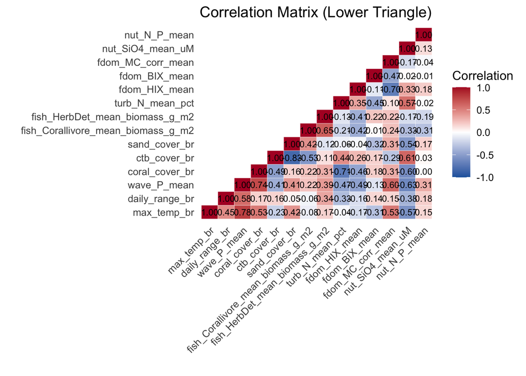

```r
# Select numeric predictors only
env_num <- env_predictors_raw %>%
  select(-site.name)

# Compute correlation matrix
cor_mat <- cor(env_num, use = "pairwise.complete.obs", method = "pearson")

cor_mat[upper.tri(cor_mat)] <- NA
cor_long <- melt(cor_mat, na.rm = TRUE)

ggplot(cor_long, aes(Var1, Var2, fill = value)) +
  geom_tile(color = "white") +

  # Add correlation values
  geom_text(aes(label = sprintf("%.2f", value)),
            color = "black", size = 3) +

  scale_fill_gradient2(
    low = "#2166AC", mid = "white", high = "#B2182B",
    midpoint = 0, limits = c(-1,1), name = "Correlation"
  ) +
  theme_minimal(base_size = 12) +
  theme(
    axis.text.x = element_text(angle = 45, hjust = 1),
    panel.grid = element_blank()
  ) +
  labs(
    x = "",
    y = "",
    title = "Correlation Matrix (Lower Triangle)"
  )
```

SANITY CHECKS what predictor variable sites were chosen as closest to the coral density sites?

```r
plot_link_map <- function(df,
                          coral_lon, coral_lat,
                          pred_lon, pred_lat,
                          coral_label,
                          value_cols,
                          title_prefix = "") {

  df_long <- df %>%
    dplyr::select(all_of(c(coral_lon, coral_lat,
                           pred_lon, pred_lat,
                           coral_label,
                           value_cols))) %>%
    tidyr::pivot_longer(
      cols      = all_of(value_cols),
      names_to  = "variable",
      values_to = "value"
    )

  ggplot(df_long) +
    # line from coral site to predictor site
    geom_segment(
      aes(
        x    = .data[[coral_lon]],
        y    = .data[[coral_lat]],
        xend = .data[[pred_lon]],
        yend = .data[[pred_lat]]
      ),
      colour = "grey70",
      alpha  = 0.7
    ) +
    # predictor station
    geom_point(
      aes(
        x     = .data[[pred_lon]],
        y     = .data[[pred_lat]],
        colour = value
      ),
      size = 2
    ) +
    # coral site
    geom_point(
      aes(
        x = .data[[coral_lon]],
        y = .data[[coral_lat]]
      ),
      shape  = 21,
      fill   = "white",
      size   = 2.5,
      colour = "black"
    ) +
    # coral site labels
    geom_text(
      aes(
        x     = .data[[coral_lon]],
        y     = .data[[coral_lat]],
        label = .data[[coral_label]]
      ),
      vjust = -0.7,
      size  = 2.8
    ) +
    coord_equal() +  # keep true geography
    scale_colour_viridis_c(option = "C") +
    facet_wrap(~ variable, ncol = 2) +  # fixed scales to avoid conflict
    theme_minimal(base_size = 11) +
    theme(
      panel.grid        = element_blank(),
      strip.background  = element_rect(fill = "grey95", colour = NA),
      axis.title.x      = element_text(margin = margin(t = 5)),
      axis.title.y      = element_text(margin = margin(r = 5))
    ) +
    labs(
      x     = "Longitude",
      y     = "Latitude",
      colour = "Value",
      title = title_prefix
    )
}
```

fDOM

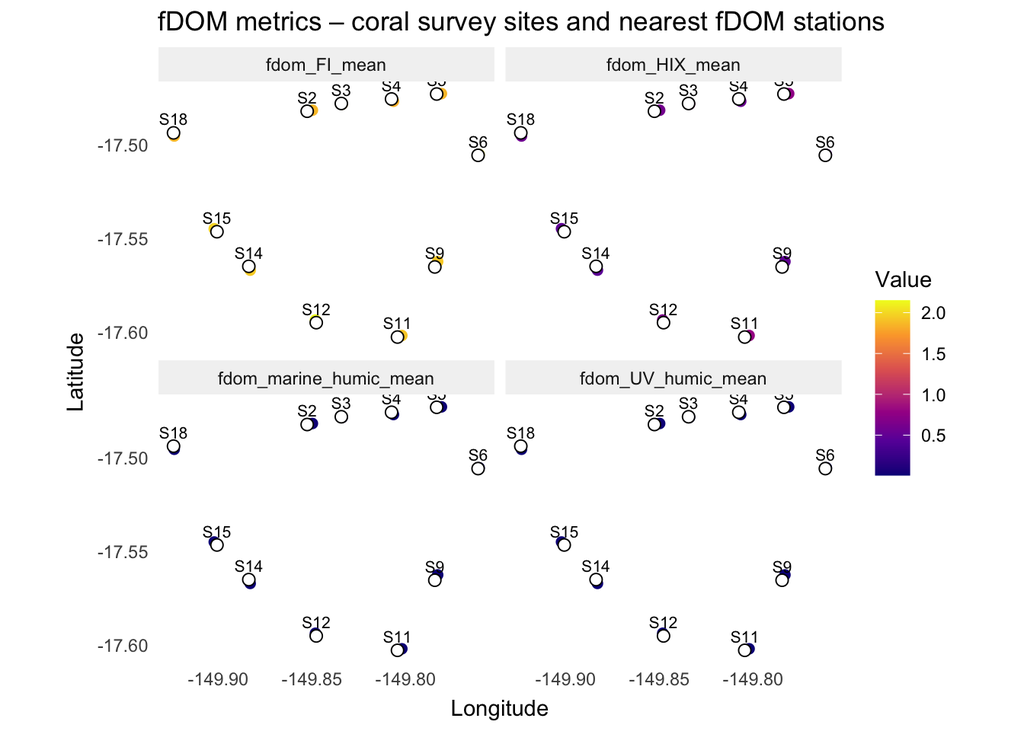

```r
fdom_value_cols <- c(
  "fdom_HIX_mean",
  "fdom_FI_mean",
  "fdom_UV_humic_mean",
  "fdom_marine_humic_mean"
)

plot_link_map(
  df          = sites_fdom,
  coral_lon   = "long",
  coral_lat   = "lat",
  pred_lon    = "fdom_long",
  pred_lat    = "fdom_lat",
  coral_label = "site.name",
  value_cols  = fdom_value_cols,
  title_prefix = "fDOM metrics – coral survey sites and nearest fDOM stations"
)
```

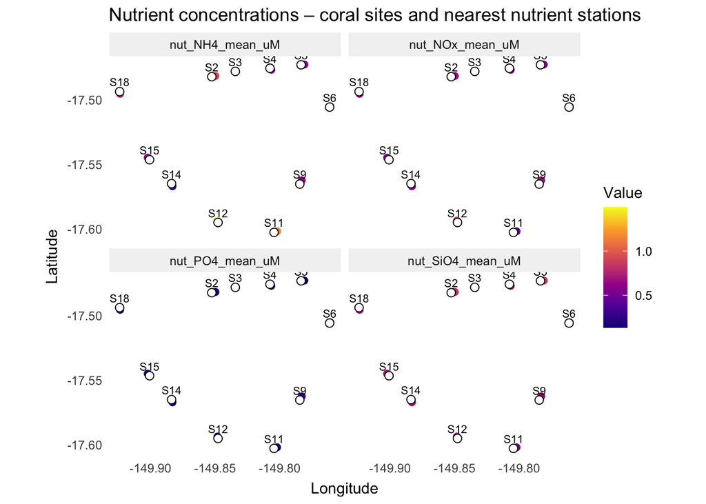

```r
## From the nutrient spatial metadata (1048 dt1)
nut_spatial_coords <- turbinaria_sites %>%      # <-- whatever you named dt1
  dplyr::select(
    nut_site_id = Site,
    nut_long    = Longitude,
    nut_lat     = Latitude
  )

## Attach coordinates of the nearest nutrient site to each coral site
nut_by_coral_loc <- nut_by_coral %>%
  dplyr::left_join(
    nut_spatial_coords,
    by = c("nut_site_id_near" = "nut_site_id")
  )


nut_value_cols <- c(
  "nut_PO4_mean_uM",
  "nut_SiO4_mean_uM",
  "nut_NOx_mean_uM",
  "nut_NH4_mean_uM"
)

plot_link_map(
  df          = nut_by_coral_loc,
  coral_lon   = "long",
  coral_lat   = "lat",
  pred_lon    = "nut_long",
  pred_lat    = "nut_lat",
  coral_label = "site.name",
  value_cols  = nut_value_cols,
  title_prefix = "Nutrient concentrations – coral sites and nearest nutrient stations"
)
```

Benthic Data

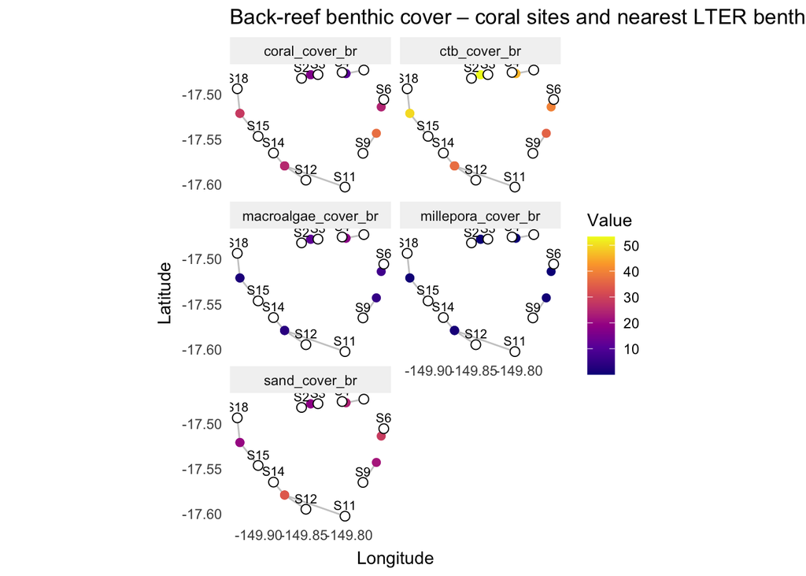

```r
benthic_value_cols <- c(
  "coral_cover_br",
  "macroalgae_cover_br",
  "ctb_cover_br",
  "sand_cover_br",
  "millepora_cover_br"
)

plot_link_map(
  df          = sites_benthic,
  coral_lon   = "long",
  coral_lat   = "lat",
  pred_lon    = "br_long",
  pred_lat    = "br_lat",
  coral_label = "site.name",
  value_cols  = benthic_value_cols,
  title_prefix = "Back-reef benthic cover – coral sites and nearest LTER benthic station"
)
```

11. Fit the boral JSDM 11.1 Align Y and X (by site names)

```r
# Extract site order from Y
Y_sites <- rownames(Y)

# Reorder X_env to match Y
X_env_aligned <- X_env %>%
  arrange(match(site, Y_sites))

# Verify alignment
stopifnot(all(rownames(Y) == X_env_aligned$site))

# Build predictor matrix X
X <- X_env_aligned %>%
  select(-site) %>%
  as.matrix()
```

11.2 Run the model

```r
set.seed(123)

boral_fit <- boral(
  y = Y,
  X = X,
  family = "normal",
  lv.control = list(num.lv = 2),
  row.eff = "none",
  save.model = TRUE,
  mcmc.control = list(
    n.burnin = 20000,
    n.iteration = 40000,
    n.thin = 20
  )
)
```

```
## module glm loaded
```

12. Model output 12.1 Model output: coefficients

```r
names(boral_fit)
```

```
##  [1] "lv.median"       "lv.mean"         "lv.iqr"          "lv.sd"
##  [5] "lv.coefs.median" "lv.coefs.mean"   "lv.coefs.iqr"    "lv.coefs.sd"
##  [9] "X.coefs.median"  "X.coefs.mean"    "X.coefs.iqr"     "X.coefs.sd"
## [13] "hpdintervals"    "jags.model"      "call"            "n"
## [17] "p"               "X"               "X.ind"           "y"
## [21] "row.eff"         "geweke.diag"     "family"          "num.lv"
## [25] "lv.control"      "num.X"           "num.traits"      "calc.ics"
## [29] "trial.size"      "prior.control"   "num.ord.levels"  "mcmc.control"
```

```r
#Environmental coefficients (predictor → taxon responses)
X_eff <- boral_fit$X.coefs.median
X_eff
```

```
##                            coefficients
## resp                         max_temp_br daily_range_br  wave_P_mean
##   P. acuta_0-2cm             0.156836139   -0.044365467  0.050382266
##   P. acuta_>2cm-5cm          0.042009629    0.129857307  0.122097738
##   P. effusa_0-2cm            0.014403707   -0.133292355 -0.036787205
##   P. effusa_>2cm-5cm         0.009798532   -0.106475633  0.050027612
##   P. grandis_0-2cm           0.097821584   -0.061055175 -0.124486853
##   P. grandis_>2cm-5cm       -0.032282028   -0.056680337  0.114561556
##   P. grandis_>5cm-14cm       0.022421066   -0.019587076  0.015409328
##   P. grandis_>14cm           0.066950441    0.013172942  0.054553269
##   P. meandrina_0-2cm         0.269432062   -0.402546199  0.075389378
##   P. meandrina_>2cm-5cm      0.118809147   -0.060326213 -0.045957843
##   P. meandrina_>5cm-14cm     0.022454811   -0.013463721 -0.048623676
##   P. meandrina_>14cm         0.124844478    0.041110962  0.113863908
##   P. tuahiniensis_0-2cm      0.119928493   -0.031986053  0.003341506
##   P. tuahiniensis_>2cm-5cm  -0.038151583   -0.044109691  0.076618180
##   P. tuahiniensis_>5cm-14cm  0.092689789    0.009752884  0.117994154
##   P. tuahiniensis_>14cm      0.103301150   -0.077858083  0.106354032
##   P. verrucosa_0-2cm         0.070682243   -0.063085804  0.148534439
##   P. verrucosa_>2cm-5cm      0.091444285   -0.004773078 -0.159558189
##   P. verrucosa_>5cm-14cm     0.081450408   -0.006827415  0.201755885
##   P. verrucosa_>14cm        -0.036748965   -0.043889828  0.087144239
##   P. acuta_>14cm            -0.012312801    0.061504216 -0.178442145
##   P. effusa_>5cm-14cm        0.047931036   -0.065748639  0.022382318
##   P. effusa_>14cm           -0.034080739    0.075747763 -0.035347238
##   P. acuta_>5cm-14cm         0.025922036    0.051459698 -0.012379366
##                            coefficients
## resp                        coral_cover_br ctb_cover_br sand_cover_br
##   P. acuta_0-2cm              -0.066822762  0.011248377   0.079760879
##   P. acuta_>2cm-5cm           -0.067868829 -0.161641333  -0.073036875
##   P. effusa_0-2cm             -0.112914004  0.020270300   0.030350223
##   P. effusa_>2cm-5cm          -0.090102015  0.077425914  -0.059710275
##   P. grandis_0-2cm            -0.013781821  0.096128212   0.017451045
##   P. grandis_>2cm-5cm         -0.090115179 -0.005666915   0.031766750
##   P. grandis_>5cm-14cm         0.004571000  0.105927007   0.016049946
##   P. grandis_>14cm             0.071491260 -0.028415725  -0.003984157
##   P. meandrina_0-2cm          -0.133958746  0.076378402   0.011007678
##   P. meandrina_>2cm-5cm       -0.006761321 -0.102458283   0.032148129
##   P. meandrina_>5cm-14cm      -0.158104080  0.140210480   0.298619276
##   P. meandrina_>14cm          -0.141785159  0.074910466   0.081431411
```

[output cut: 101 more lines]

```
##   P. meandrina_>2cm-5cm          0.062035438  0.010587146
##   P. meandrina_>5cm-14cm         0.075305674 -0.046417187
##   P. meandrina_>14cm             0.132606782 -0.060598519
##   P. tuahiniensis_0-2cm         -0.033816297  0.011456548
##   P. tuahiniensis_>2cm-5cm      -0.035166949 -0.110101615
##   P. tuahiniensis_>5cm-14cm      0.021771285 -0.072509448
##   P. tuahiniensis_>14cm         -0.063194222 -0.014162772
##   P. verrucosa_0-2cm            -0.003867852  0.024209815
##   P. verrucosa_>2cm-5cm         -0.018653424  0.062758679
##   P. verrucosa_>5cm-14cm        -0.042065721 -0.067221206
##   P. verrucosa_>14cm            -0.046033259 -0.014300167
##   P. acuta_>14cm                -0.046838830  0.075184181
##   P. effusa_>5cm-14cm            0.083757853 -0.003714016
##   P. effusa_>14cm               -0.098291456  0.061484867
##   P. acuta_>5cm-14cm             0.035805344  0.026314396
```

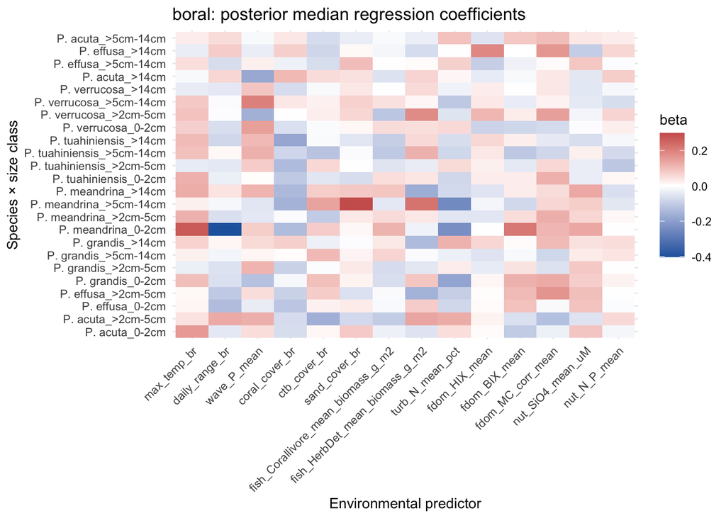

```r
X_long <- melt(X_eff, varnames = c("response", "predictor"), value.name = "beta")

ggplot(X_long, aes(predictor, response, fill = beta)) +
  geom_tile() +
  scale_fill_gradient2(
    low = "#2166AC", mid = "white", high = "#B2182B",
    midpoint = 0
  ) +
  theme_minimal(base_size = 10) +
  theme(axis.text.x = element_text(angle = 45, hjust = 1)) +
  labs(
    x = "Environmental predictor",
    y = "Species × size class",
    title = "boral: posterior median regression coefficients"
  )
```

12.2 Residual correlations

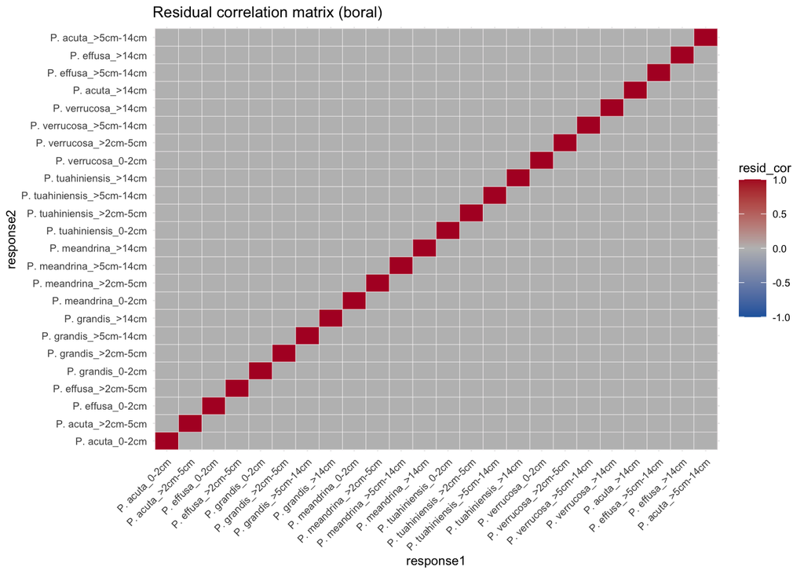

```r
res_cor <- get.residual.cor(boral_fit)

res_long <- melt(res_cor, varnames = c("response1", "response2"),
                 value.name = "resid_cor") %>%
  filter(!is.na(response1))

ggplot(res_long, aes(response1, response2, fill = resid_cor)) +
  geom_tile(color = "white") +
  scale_fill_gradient2(
    low = "#2166AC", mid = "gray", high = "#B2182B",
    midpoint = 0, limits = c(-1,1)
  ) +
  theme_minimal(base_size = 8) +
  theme(axis.text.x = element_text(angle = 45, hjust = 1)) +
  labs(title = "Residual correlation matrix (boral)")
```

12.3 Plot taxa ordination

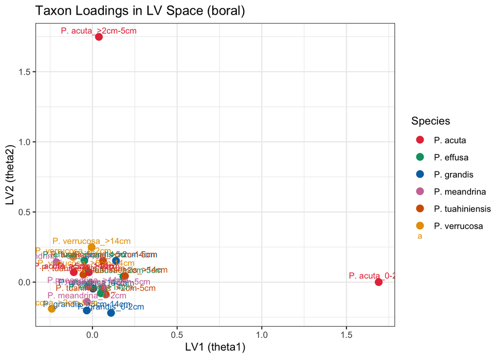

```r
## Extract LV loadings from boral
loadings <- boral_fit$lv.coefs.median
L <- as.data.frame(loadings)
L$taxon <- rownames(L)

## Extract species name (before first underscore)
L$species <- sub("_.*", "", L$taxon)

## Define your custom species color palette
species_cols <- c(
  "P. tuahiniensis" = "#D55E00",
  "P. meandrina"    = "#CC79A7",
  "P. verrucosa"    = "#E69F00",
  "P. grandis"      = "#0072B2",
  "P. effusa"       = "#009E73",
  "P. acuta"        = "#e63946"
)

## Plot LV1 vs LV2 with species colors
ggplot(L, aes(theta1, theta2, label = taxon, color = species)) +
  geom_point(size = 3) +
  geom_text(vjust = -0.6, size = 3) +
  scale_color_manual(values = species_cols) +
  theme_bw() +
  labs(
    title = "Taxon Loadings in LV Space (boral)",
    x = "LV1 (theta1)",
    y = "LV2 (theta2)",
    color = "Species"
  )
```